# TOSCA Version 2.0

## 9.2 Data Type

A *data type* defines the schema for user-defined data types in TOSCA. User-defined data types comprise *derived types* that derive from from the TOSCA built-in types and *complex types* that define collections of properties that each have their own data types.

A data type definition is a type of TOSCA type definition and as a result supports the common keynames listed in the section Common Keynames in Type Definitions . In addition, the data type definition has the following recognized keynames:

| Keyname | Mandatory | Type | Description |
| --- | --- | --- | --- |
| `validation` | no | validation clause | The optional validation clause that must evaluate to True for values of this data type to be valid. |
| `properties` | no | map of property definitions | The optional map property definitions that comprise the schema for a complex data type in TOSCA. |
| `key_schema` | conditional | schema definition | For data types that derive from the TOSCA `map` data type, the optional schema definition for the keys used to identify entries in properties of this data type. If not specified, the `key_schema` defa… |
| `entry_schema` | conditional | schema definition | For data types that derive from the TOSCA `list` or `map` data types, the mandatory schema definition for the entries in properties of this data type. For data types that do not derive from the TOSCA … |

These keynames can be used according to the following grammar:

```yaml
<data_type_name>:
  derived_from: <existing_type_name>
  version: <version_number>
  metadata:
    <metadata_name_1>: <metadata_value_1>
    <metadata_name_2>: <metadata_value_2>
    ...
  description: <datatype_description>
  validation: <validation_clause>
  properties:
    <property_def_1>
    <property_def_2>
    ...
  key_schema: <key_schema_def>
  entry_schema: <entry_schema_def>
```

In the above grammar, the placeholders that appear in angle brackets have the following meaning:

- `<data_type_name>`: represents the mandatory symbolic name of the data type as a string.
- `<existing_type_name>`: represents the optional name of a valid TOSCA built-in type or data type from which this new data type derives.
- `<validation_clause>`: represents the optional validation clause that must evaluate to True for values of this data type to be valid.
- `<property_def_*>`: represents the optional map of one or more property definitions that provide the schema for the data type
  - `<property_def_*>` are only allowed for complex type definitions and MAY NOT be added to custom data types `derived_from` TOSCA built-in types.
- `<key_schema_def>`: if the data type derives from the TOSCA `map` type (i.e `<existing_type_name>` is a `map` or derives from a `map`), it represents the optional schema definition for the keys used to identify entry properties of this type.
- `<entry_schema_def>`: if the data type derives from the TOSCA `map` or `list` types (i.e. `<existing_type>` name is a `list` or `map` or derives from a `list` or `map`), it represents the mandatory schema definition for the entries in properties of this type.

The following requirements apply:

- A valid datatype definition MUST have either a valid `derived_from` declaration or at least one valid property definition.
- A validation clause SHALL be type-compatible with the type declared by the `derived_from` keyname.
- If a `properties` keyname is provided, it SHALL contain one or more valid property definitions.

During data type derivation the keyname definitions follow these rules:

- `validation`: a new validation clause may be defined; this validation clause does not replace the validation clause defined in the parent type but is considered in addition to it.
- `properties`: existing property definitions may be refined; new property definitions may be added.
- `key_schema`: the `key_schema` definition may be refined according to schema refinement rules.
- `entry_schema`: the `entry_schema` definition may be refined according to schema refinement rules.

The following code snippet shows an example data type definition that derives from the built-in "string" type:

```yaml
  ShortString:
    derived_from: string
    validation: { $less_or_equal: [ { $length: [ $value ] }, 16 ] }
```

The next example defines a complex data type that represents a phone number:

```yaml
  PhoneNumber:
    properties:
      country-code:
        type: integer
      area-code:
        type: integer
      number:
        type: integer
```

The following example shows a complex data type that derives from and extends a previously defined complex data type:

```yaml
  ExtendPhoneNumber:
    derived_from: PhoneNumber
    properties:
      phone-description:
        type: string
        validation: { $less_or_equal: [ { $length: [ $value ] }, 128 ] }
```

## 9.3 Schema Definition

All entries in a `list` or `map` for one property or parameter must be of the same type. Similarly, all keys for map entries for one property or parameter must be of the same type as well. A TOSCA schema definition must be used to specify the type (for simple entries) or schema (for complex entries) for keys and entries in TOSCA set types such as the TOSCA `list` or `map`.

If the schema definition specifies a map key, the type of the key schema must be derived originally from the string type (which basically ensures that the schema type is a string with additional validation clause). As there is little need for complex keys this caters to more straight-forward and clear specifications. If the key schema is not defined it is assumed to be string by default.

Schema definitions appear in data type definitions when `derived_from` a `list` or `map` type or in parameter, property, or attribute definitions of a `list` or `map` type.

The following is the list of recognized keynames for a TOSCA schema definition:

| Keyname | Mandatory | Type | Description |
| --- | --- | --- | --- |
| `type` | yes | str | The mandatory data type for the key or entry. If this schema definition is for a map key, then the referred type must be derived originally from string. |
| `description` | no | str | The optional description for the schema. |
| `validation` | no | validation clause | The optional validation clause that must evaluate to True for the property. |
| `key_schema` | no | schema definition | When the schema itself is of type `map`, the optional schema definition that is used to specify the type of the keys of that map's entries (if `key_schema` is not defined it is assumed to be "string" … |
| `entry_schema` | conditional | schema definition | When the schema itself is of type `list` or `map`, the schema definition is mandatory and is used to specify the type of the entries in that map or list. For other schema types, the `entry_schema` mus… |

These keynames can be used according to the following grammar:

```yaml
<schema_def>:
  type: <schema_type>
  description: <schema_description>
  metadata:
    <metadata_name_1>: <metadata_value_1>
    <metadata_name_2>: <metadata_value_2>
    ...
  validation: <schema_validation_clause>
  key_schema: <key_schema_def>
  entry_schema: <entry_schema_def>
```

The following single-line grammar may be used when only the schema type needs to be declared:

```yaml
<schema_def>: <schema_type>
```

In the above grammars, the placeholders that appear in angle brackets have the following meaning:

- `<schema_type>`: represents the mandatory type name for entries of the specified schema
  - if this schema definition is for a map key, then the schema_type must be derived originally from string.
- `<schema_validation_clause>`: represents the optional validation clause for entries of the specified schema.
- `<key_schema_def>`: if the `<schema_type>` is `map`, it represents the optional schema definition for the keys of that map's entries.
- `<entry_schema_def>`: if the `<schema_type>` is `list` or `map`, it represents the mandatory schema definition for the entries in that map or list.

A schema definition uses the following definition refinement rules when the containing entity type is derived:

- `type`: must be derived from (or the same as) the type in the schema definition in the parent entity type definition.
- `description`: a new definition is unrestricted and will overwrite the one inherited from the schema definition in the parent entity type definition.
- `validation`: a new definition is unrestricted; this validation clause does not replace the validation clause defined in the schema definition in the parent entity type but is considered in addition to it.
- `key_schema`: may be refined (recursively) according to schema refinement rules.
- `entry_schema`: may be refined (recursively) according to schema refinement rules.

## 9.4 Property Definition

A *property definition* defines a named, typed value and related data that can be associated with an entity defined in this specification (e.g., node types, relationship types, capability types, etc.). Properties are used by template authors to provide configuration values to TOSCA entities that indicate their *desired state* when they are instantiated. The value of a property can be retrieved using the `$get_property` function within TOSCA service templates.

The following is the list of recognized keynames for a TOSCA property definition:

| Keyname | Mandatory | Type | Description |
| --- | --- | --- | --- |
| `type` | yes | str | The mandatory data type for the property. |
| `description` | no | str | The optional description for the property. |
| `metadata` | no | map of metadata | Defines a section used to declare additional information. |
| `required` | no | bool | An optional key that declares a property as required (true) or not (false). Defaults to true. |
| `default` | no | <must match property type> | An optional key that may provide a value to be used as a default if not provided by another means. The `default` keyname SHALL NOT be defined when property is not required (i.e. the value of the `requ… |
| `value` | no | <see below> | An optional key that may provide a fixed value to be used. A property that has a fixed value provided (as part of a definition or refinement) cannot be subject to a further refinement or assignment. T… |
| `validation` | no | validation clause | The optional validation clause for the property. |
| `key_schema` | conditional | schema definition | The schema definition for the keys used to identify entries in properties of type `map` (or types that derive from `map`). If not specified, the `key_schema` defaults to string. For properties of type… |
| `entry_schema` | conditional | schema definition | The schema definition for the entries in properties of collection types such as `list`, `map`, or types that derive from `list` or `map`. If the property type is a collection type, `entry_schema` is m… |

Property definitions have the following grammar:

```yaml
<property_name>:
  type: <property_type>
  description: <property_description>
  required: <property_required>
  default: <default_value>
  value: <property_value> | <property_value_expression>
  status: <status_value>
  validation: <validation_clause>
  key_schema: <key_schema_def>
  entry_schema: <entry_schema_def>
  metadata:
    <metadata_name_1>: <metadata_value_1>
    <metadata_name_2>: <metadata_value_2>
    ...
```

The following single-line grammar is supported when only a fixed value or fixed value expression needs to be provided to a property:

```yaml
<property_name>: <property_value> | <property_value_expression>
```

This single-line grammar is equivalent to the following:

```yaml
<property_name>:
  value: <property_value> | <property_value_expression>
```

Note that the short form can be used only during a refinement (i.e. the property has been previously defined).

In the above grammar, the placeholders that appear in angle brackets have the following meaning:

- `<property_name>`: represents the mandatory symbolic name of the property as a string.
- `<property_type>`: represents the mandatory data type of the property.
- `<property_required>`: represents an optional Boolean value (true or false) indicating whether or not the property is required. If this keyname is not present on a property definition, then the property SHALL be considered required (i.e., true) by default.
- `<default_value>`: contains a type-compatible value that is used as a default value if a value is not provided by another means (via the fixed value definition or via property assignment);
  - the `<default_value>` shall not be defined for properties that are not required (i.e. `<property_required>` is "false") as they will stay undefined.
- `<property_value>` or `<property_value_expression>`: contains a type-compatible value or value expression that may be defined during property definition or refinement to set and fix the value definition of the property.
  - note that a value definition cannot be changed; once defined, the property cannot be further refined or assigned. Thus, value definitions should be avoided in `data_type` definitions.
- `<validation_clause>`: represents the optional Boolean expression that must evaluate to true for a value of this property to be valid.
- `<key_schema_def>`: if the `<property_type>` is `map` or derives from `map`, represents the optional schema definition for the keys used to identify entries in that map.
- `<entry_schema_def>`: if the `<property_type>` is `list` or `map`, or derives from `list` or `map`, represents the mandatory schema definition for the entries in that map or list.

A property definition within data, capability, node, relationship, group, policy, and artifact types (including capability definitions in node types) matching the name of a property in the derived entity type uses the following refinement rules to combine the two property definitions together:

- `type`: must be derived from (or the same as) the type in the property definition in the parent entity type definition.
- `description`: a new definition is unrestricted and will overwrite the one inherited from the property definition in the parent entity type definition.
- `required`: if defined to "false" in the property definition parent entity type it may be redefined to "true"; note that if undefined it is automatically considered as being defined to "true".
- `default`: a new definition is unrestricted and will overwrite the one inherited from the property definition in the parent entity type definition (note that the definition of a default value is only allowed if the `required` keyname is (re)defined as "true").
- `value`: if undefined in the property definition in the parent entity type, it may be defined to any type-compatible value; once defined, the property cannot be further refined or assigned.
- `validation`: a new definition is unrestricted; this validation clause does not replace the validation clause defined in the property definition in the parent entity type but is considered in addition to it.
- `key_schema`: if defined in the property definition in the parent entity type it may be refined according to schema refinement rules.
- `entry_schema`: if defined in the property definition in the parent entity type it may be refined according to schema refinement rules.

The following code snippet shows an example property definition with a validation clause:

```yaml
    properties:
      num-cpus:
        type: integer
        description: Number of CPUs requested for a software node instance.
        default: 1
        required: true
        validation: { $valid_values: [ $value, [ 1, 2, 4, 8 ] ] }
```

The following shows an example of a property refinement. Consider the definition of an Endpoint capability type:

```yaml
  Endpoint:
    properties:
      protocol:
        type: string
        required: true
        default: tcp
      port:
        type: PortDef
        required: false
      secure:
        type: boolean
        required: false
        default: false
```

The "Endpoint.Admin" capability type refines the secure property of the "Endpoint" capability type from which it derives by forcing its value to always be true:

```yaml
# In a capability refinement.
  Endpoint.Admin:
    derived_from: Endpoint
    # Change Endpoint secure indicator to true from its default of false
    properties:
      secure: true
# Or in a node definition.
node_types:
  WebServer:
    description: A web server
    capabilities:
      connection-point:
        type: Endpoint
service_template:
  node_templates:
    my_server:
      type: WebServer
      capabilities:
        connection-point:
          properties:
            secure: true
```

## 9.5 Property Assignment

A *property assignment* is used to assign a value to a property within a TOSCA template. A TOSCA property assignment has no keynames. Property assignments have the following grammar:

```yaml
<property_name>: <property_value> | <property_value_expression>
```

In the above grammar, the placeholders that appear in angle brackets have the following meaning:

- `<property_name>`: represents the name of a property that will be used to select a property definition with the same name within on a TOSCA entity (e.g., node template, relationship template, etc.) which is declared in its declared type (e.g., a node type, node template, capability type, etc.).
- `<property_value>`, `<property_value_expression>`: represent the type-compatible value to assign to the property. Property values may be provided as the result of the evaluation of an expression or a function.

The following requirements apply:

- Properties that have a (fixed) value defined during their definition or during a subsequent refinement may not be assigned (as their value is already set).
- If a required property has no value defined or assigned, its default value is assigned
- A non-required property that is not assigned stays undefined, thus the `default` keyname is irrelevant for a non-required property.

## 9.6 Attribute Definition

An *attribute definition* defines a named, typed value that can be associated with an entity defined in this specification (e.g., a node, relationship or capability type). Specifically, it is used to expose the *actual state* of some a TOSCA entity after it has been deployed and instantiated (as set by the TOSCA orchestrator).

Attribute definitions are very similar to property definitions; however, properties of entities reflect a configuration value that carries the template author's requested or desired value (i.e., desired state) which the orchestrator (attempts to) use when instantiating the entity. Attributes on the other hand reflect the actual value (i.e., actual state) that provides the actual instantiated value. For example, a property can be used to request the IP address of a node using a property (setting); however, the actual IP address after the node is instantiated may by different and made available by an attribute. To allow both the desired state and the actual state to be tracked, TOSCA orchestrators MUST automatically create an attribute for every declared property (with the same symbolic name) to allow introspection of both the desired state (property) and actual state (attribute). If an attribute is reflected from a property, its initial value is the value of the reflected property.

Attribute values can be retrieved via the `$get_attribute` function from the representation model and used as values to other entities within TOSCA service templates. Attribute values an also be set by output mappings defined in interface operations.

The following is the list of recognized keynames for a TOSCA attribute definition:

| Keyname | Mandatory | Type | Description |
| --- | --- | --- | --- |
| `type` | yes | str | The mandatory data type for the attribute. |
| `description` | no | str | The optional description for the attribute. |
| `metadata` | no | map of metadata | Defines a section used to declare additional information. |
| `default` | no | <must match attribute type> | An optional key that may provide a value to be used as a default if not provided by another means. This value SHALL be type compatible with the type declared by the attribute definition's `type` keyna… |
| `validation` | no | validation clause | The optional validation clause for the attribute. |
| `key_schema` | conditional | schema definition | The schema definition for the keys used to identify entries in attributes of type TOSCA map (or types that derive from map). If not specified, the key_schema defaults to string. For attributes of type… |
| `entry_schema` | conditional | schema definition | The schema definition for the entries in attributes of collection types such as `list`, `map`, or types that derive from `list` or `map`) If the attribute type is a collection type, `entry_schema` is … |

Attribute definitions have the following grammar:

```yaml
attributes:
  <attribute_name>:
    type: <attribute_type>
    description: <attribute_description>
    metadata:
      <metadata_name_1>: <metadata_value_1>
      <metadata_name_2>: <metadata_value_2>
      ...
    default: <default_value>
    validation: <attribute_validation_clause>
    key_schema: <key_schema_def>
    entry_schema: <entry_schema_def>
```

In the above grammar, the placeholders that appear in angle brackets have the following meaning:

- `<attribute_name>`: represents the mandatory symbolic name of the attribute as a string.
- `<attribute_type>`: represents the mandatory data type of the attribute.
- `<default_value>`: contains a type-compatible value that may be used as a default if not provided by another means. Values for the `default` keyname MUST be derived or calculated from other attribute or operation output values (that reflect the actual state of the instance of the corresponding resource) and not hard-coded or derived from a property settings or inputs (i.e., desired state).
- `<attribute_validation_clause>`: represents the optional validation clause that must evaluate to True for values for the defined attribute to be valid.
- `<key_schema_def>`: if the `<attribute_type>` is `map`, represents the optional schema definition for the keys used to identify entries in that map.
- `<entry_schema_def>`: if the `<attribute_type>` is `list` or `map`, represents the mandatory schema definition for the entries in that map or list.

An attribute definition within data, capability, node, relationship, and group types (including capability definitions in node types) uses the following refinement rules when the containing entity type is derived:

- `type`: must be derived from (or the same as) the type in the attribute definition in the parent entity type definition.
- `description`: a new definition is unrestricted and will overwrite the one inherited from the attribute definition in the parent entity type definition.
- `default`: a new definition is unrestricted and will overwrite the one inherited from the attribute definition in the parent entity type definition.
- `validation`: a new definition is unrestricted; this validation clause does not replace the validation clause defined in the attribute definition in the parent entity type but is considered in addition to it.
- `key_schema`: if defined in the attribute definition in the parent entity type it may be refined according to schema refinement rules.
- `entry_schema`: if defined in the attribute definition in the parent entity type it may be refined according to schema refinement rules.

The following represents a mandatory attribute definition:

```yaml
      actual_cpus:
        type: integer
        description: Actual number of CPUs allocated to the node instance.
```

## 9.7 Attribute Assignment

An attribute assignment is used to assign a value to an attribute within a TOSCA template. A TOSCA attribute assignment has no keynames. Attribute assignments have the following grammar:

```yaml
<attribute_name>: <attribute_value> | <attribute_value_expression>
```

In the above grammar, the placeholders that appear in angle brackets have the following meaning:

- `<attribute_name>`: represents the name of an attribute that will be used to select an attribute definition with the same name within on a TOSCA entity (e.g., node template, relationship template, etc.) which is declared (or reflected from a Property definition) in its declared type (e.g., a node type, node template, capability type, etc.).
- `<attribute_value>`, `<attribute_value_expresssion>`: represent the type-compatible value to assign to the attribute. Attribute values may be provided as the result from the evaluation of an expression or a function.

Note that attributes that are the target of a parameter mapping assignment cannot also be assigned a value using an attribute assignment.

## 9.8 Parameter Definition

A *parameter definition* defines a named, typed value and related data that may be used to exchange values between the TOSCA orchestrator and the external world. Such values may be

- inputs and outputs of interface operations and notifications
- inputs and outputs of workflows
- inputs and outputs of service templates

From the perspective of the TOSCA orchestrator such parameters are either *incoming* (i.e. transferring a value from the external world to the orchestrator) or *outgoing* (transferring a value from the orchestrator to the external world). Thus:

- outgoing parameters are:
  - template outputs
  - internal workflow outputs
  - external workflow inputs
  - operation inputs
- incoming parameters are:
  - template inputs
  - internal workflow inputs
  - external workflow outputs
  - operation outputs
  - notification outputs

An *outgoing* parameter definition is essentially the same as a TOSCA property definition, however it may optionally inherit the data type of the value assigned to it rather than have an explicit data type defined.

An *incoming* parameter definition may define an attribute mapping of the parameter value to an attribute of a node. Optionally, it may inherit the data type of the attribute it is mapped to, rather than have an explicit data type defined for it.

The TOSCA parameter definition has all the keynames of a TOSCA property definition with the following additional or changed keynames:

| Keyname | Mandatory | Type | Description |
| --- | --- | --- | --- |
| `type` | no | str | The data type of the parameter. While this keyname is mandatory for a TOSCA Property definition, it is not mandatory for a TOSCA parameter definition. |
| `value` | no | <must match parameter type> | The type-compatible value to assign to the parameter. Parameter values may be provided as the result from the evaluation of an expression or a function. May only be defined for outgoing parameters. Mu… |
| `mapping` | no | attribute selection format | A mapping that specifies the node or relationship attribute into which the returned output value must be stored. May only be defined for incoming parameters. Mutually exclusive with the `value` keynam… |

Parameter definitions have the following grammar:

```yaml
<parameter_name>:
  type: <parameter_type>
  description: <parameter_description>
  metadata:
    <metadata_name_1>: <metadata_value_1>
    <metadata_name_2>: <metadata_value_2>
    ...
  value: <parameter_value> | <parameter_value_expression>
  mapping: <attribute_selection_format>
  required: <parameter_required>
  default: <parameter_default_value>
  validation: <parameter_validation_clause>
  key_schema: <key_schema_def>
  entry_schema: <entry_schema_def>
```

The following single-line grammar is supported for *outgoing* parameter definitions when only a fixed value needs to be provided:

```yaml
<parameter_name>: <parameter_value> |  <parameter_value_expression>
```

This single-line grammar is equivalent to the following:

```yaml
<parameter_name>:
    value: <parameter_value> |  <parameter_value_expression>
```

The following single-line grammar is supported for *incoming* parameter definitions when only a parameter to attribute mapping needs to be provided:

```yaml
<parameter_name>: <attribute_selection_form>
```

This single-line grammar is equivalent to the following:

```yaml
<parameter_name>:
    mapping: <attribute_selection_form>
```

Note that the context of the parameter definition unambiguously determines if the parameter is an incoming or an outgoing parameter.

In the above grammar, the placeholders that appear in angle brackets have the following meaning:

- `<parameter_name>`: represents the mandatory symbolic name of the parameter as a string.
- `<parameter_type>`: represents the optional data type of the parameter. Note, this keyname is mandatory for a TOSCA Property definition, but is not for a TOSCA Parameter definition.
- `<parameter_value>`, `<parameter_value_expresssion>`: represent the type-compatible value to assign to the parameter. Parameter values may be provided as the result from the evaluation of an expression or a function.
  - once the `value` keyname is defined, the parameter cannot be further refined or assigned.
  - the `value` keyname is relevant only for *outgoing* parameter definitions and SHOULD NOT be defined in *incoming* parameter definitions.
- `<parameter_required>`: represents an optional Boolean value (true or false) indicating whether or not the parameter is required. If this keyname is not present on a parameter definition, then the parameter SHALL be considered required (i.e., true) by default.
- `<default_value>`: contains a type-compatible value that may be used as a default if not provided by other means.
  - the `default` keyname SHALL NOT be defined for parameters that are not required (i.e. `<parameter_required>` is "false") as they will stay undefined.
- `<parameter_validation_clause>`: represents the optional validation clause on the parameter definition.
- `<key_schema_def>`: if the `<parameter_type>` is `map`, represents the optional schema definition for the keys used to identify entries in that map. Note that if the `key_schema` is not defined, the `key_schema` defaults to string.
- `<entry_schema_def>`: if the `<parameter_type>` is `list` or `map`, represents the mandatory schema definition for the entries in that map or list.
- `<attribute_selection_format>`: a list that corresponds to a valid attribute selection format; the parameter is mapped onto an attribute of the containing entity
  - the `mapping` keyname is relevant only for *incoming* parameter definitions and SHOULD NOT be defined in *outgoing* parameter definitions.

A parameter definition within interface types, interface definitions in node and relationship types, uses the following refinement rules when the containing entity type is derived:

- `type`: must be derived from (or the same as) the type in the parameter definition in the parent entity type definition.
- `description`: a new definition is unrestricted and will overwrite the one inherited from the parameter definition in the parent entity type definition.
- `required`: if defined to "false" in the parameter definition parent entity type it may be redefined to "true"; note that if undefined it is automatically considered as being defined to "true".
- `default`: a new definition is unrestricted and will overwrite the one inherited from the parameter definition in the parent entity type definition (note that the definition of a default value is only allowed if the `required` keyname is (re)defined as "true").
- `value`: if undefined in the parameter definition in the parent entity type, it may be defined to any type-compatible value; once defined, the parameter cannot be further refined or assigned
  - the `value` keyname should be defined only for *outgoing* parameters.
- `mapping`: if undefined in the parameter definition in the parent entity type, it may be defined to any type-compatible attribute mapping; once defined, the parameter cannot be further refined or mapped
  - the `mapping` keyname should be defined only for *incoming* parameters.
  - status: a new definition is unrestricted and will overwrite the one inherited from the parameter definition in the parent entity type definition.
- `validation`: a new definition is unrestricted; this validation clause does not replace the validation clause defined in the parameter definition in the parent entity type but is considered in addition to it.
- `key_schema`: if defined in the parameter definition in the parent entity type it may be refined according to schema refinement rules.
- `entry_schema`: if defined in the parameter definition in the parent entity type it may be refined according to schema refinement rules.
- `metadata`: a new definition is unrestricted and will overwrite the one inherited from the parameter definition in the parent entity type definition.

The following represents an example of an input parameter definition with a validation clause:

```yaml
  inputs:
    cpus:
      type: integer
      description: Number of CPUs for the server.
      validation: { $valid_values: [ $value, [ 1, 2, 4, 8 ] ] }
```

The following represents an example of an (untyped) output parameter definition:

```yaml
  outputs:
    server-ip:
      description: The private IP address of the provisioned server.
      value: { $get_attribute: [ my-server, private-address ] }
```

A *parameter value assignment* is used to assign a value to an *outgoing* parameter within a TOSCA template. A TOSCA parameter value assignment has no keynames. Parameter value assignments have the following grammar:

```yaml
<parameter_name>: <parameter_value> | <parameter_value_expression>
```

In the above grammar, the placeholders that appear in angle brackets have the following meaning:

- `<parameter_name>`: represents the symbolic name of the parameter to assign; note that in some cases, even parameters that do not have a corresponding definition in the entity type of the entity containing them may be assigned (see e.g. inputs and outputs in interfaces).
- `<parameter_value>`, `<parameter_value_expression>`: represent the type-compatible value to assign to the parameter. Parameter values may be provided as the result from the evaluation of an expression or a function.

The following requirements apply:

- Parameters that have a (fixed) value defined during their definition or during a subsequent refinement may not be assigned (as their value is already set).
- If a required parameter has no value defined or assigned, its default value is assigned.
- A non-required parameter that has no value assigned it stays undefined, thus the `default` keyname is irrelevant for a non-required parameter.

## 9.10 Parameter Mapping Assignment

A *parameter mapping assignment* is used to define the mapping of an *incoming* parameter value (e.g. an output value that is expected to be returned by an operation implementation) to an attribute into which the returned *incoming* parameter value must be stored. A TOSCA parameter value assignment has no keynames. Parameter value assignments use the following grammar:

```yaml
<parameter_name>: [ <tosca_path>, <attribute_name>, <nested_attribute_name_or_index_or_key_1>, <nested_attribute_name_or_index_or_key_2>, ... ]
```

In the above grammars, the placeholders that appear in angle brackets have the following meaning:

- `<parameter_name>`: represents the symbolic name of the parameter to assign assign; note that in some cases, even parameters that do not have a corresponding definition in the entity type of the entity containing them may be assigned (see e.g. inputs and outputs in interfaces).
- `<tosca_path>`: used by the TOSCA processor to traverse the representation graph to reach the attribute into which to store the output value. Note that while the `<tosca_path>` is very powerful, its usage should be restricted to only reach attributes in the local node or local relationship or in a local capability.
- `<attribute_name>`: represents the name of the attribute in the local node or relationship context (i.e., "SELF") into which to map the value of the incoming parameter referred to by parameter_name.
- `<nested_attribute_name_or_index_or_key_*>`: Some TOSCA attributes are complex (i.e. composed as nested structures). These parameters are used to dereference into the names of these nested structures when needed. Som attributes are lists or maps. In these cases, an index or key may be provided to reference a specific entry in the list or map (identified by the previous parameter).

Note that it is possible for multiple operations to define outputs that map onto the same attribute value. For example, a "create" operation could include an output value that sets an attribute to an initial value, and the subsequent "configure" operation could then update that same attribute to a new value.

It is also possible that a node template assigns a value to an attribute that has an operation output mapped to it (including a value that is the result of calling an intrinsic function). Orchestrators could use the assigned value for the attribute as its initial value. After the operation runs that maps an output value onto that attribute, the orchestrator must then use the updated value, and the value specified in the node template will no longer be used.

Note that parameters that have a mapping defined during their definition or during a subsequent refinement may not be assigned (as their mapping is already set).

## 9.11 Validation Clause

A *validation clause* is a Boolean expression that must evaluate to True if the value for the entity it references is considered valid. Validation clauses have the following grammar:

```yaml
validation: <validation_clause>
```

In the above grammar, the placeholders that appear in angle brackets have the following meaning:

- `<validation_clause>`: represents a Boolean expression that must evaluate to True in order for values to be valid. Any Boolean expression can be used with any function with any degree of nesting.

The Boolean expression used as a validation clause must have a mechanism for referencing the value to which the expression applies. A special-purpose function is introduced for this purpose. This function is named `$value` and refers to the value used for the data type or the parameter definition that contains the validation clause.

The following shows an example of validation clauses used in data type definitions. They also illustrate the various alternatives for the `$value` function syntax:

```yaml
data_types:
  # Full function syntax for the $value function
  Count1:
    derived_from: integer
    validation: { $greater_or_equal: [ { $value: [] }, 0 ] }

  # Simple function syntax for the $value function
  Count2:
    derived_from: integer
    validation: { $greater_or_equal: [ $value, 0 ] }

  # Full function syntax with arguments
  SizeRange:
    properties:
      low:
        type: float
      high:
        type: float
    validation:
      $greater_or_equal: [ { $value: [ high ] }, { $value: [ low ] } ]
```

The following shows an example of validation clauses used in property definitions:

```yaml
node_types:
  Scalable:
    properties:
      minimum-instances:
        type: integer
        validation: { $greater_or_equal: [ $value,  0 ] }
      maximum-instances:
        type: integer
        validation:
          $greater_or_equal:
          - $value
          - $get_property: [ SELF, minimum-instances ]
      default-instances:
        type: integer
        validation:
          $and:
          - $greater_or_equal:
            - $value
            - $get_property: [ SELF, minimum-instances ]
          - $less_or_equal:
            - $value
            - $get_property: [ SELF, maximum-instances ]
        required: false
```

# 10 TOSCA Functions

The content in this section is normative unless otherwise labeled except:

- the examples
- references unless labelled as normative.

## 10.1 Function Syntax

TOSCA supports the use of functions for providing dynamic service data values at runtime. The syntax of a function has two representations:

- Any function can be represented by a YAML map with a single key, where the key is a string starting with a `$` (dollar sign) character and where the remainder of the string represents the function name. If present, the value in the key-value pair represents the function arguments.
- A function without arguments can alternatively be represented by a YAML string value, where the string starts with a `$` (dollar sign) character and where the remainder of the string represents the function name. This representation cannot be used in map keys.
- Function names may not contain the `$` character as it will conflict with the escape mechanisms described below.

Therefore, any string starting with a `$` (dollar sign) character will be interpreted as a function call. To allow for strings starting with `\$` character to be specified, the `$` character at the start of the string needs to be escaped by using `$$`(two dollar signs) characters instead. For example:

- `$$name` will represent the literal string `$name`
- `$$$item` will represent the literal string `$$item`, as only the first `$` character is escaped.

As we could have function calls that return values to be used as keys in a map, hypothetically it is possible that we use the same function call as a YAML key more than once. Because YAML does not allow for duplicate map keys, in such cases we must allow for key variation. This is achieved by adding suffixes after the function name starting with a second $ character. For example, the following is a valid map where the function "keygen" is called three times and the returned values are used as keys in the hint map:

```yaml
        hint:
          { $keygen: [ UUID ] }: 34
          { $keygen$1: [ UUID ] }: 56
          { $keygen$2: [ UUID ] }: 78
```

TOSCA functions may be used wherever a value is expected, such as:

- a value for a TOSCA keyname
- a value for a parameter or property or attribute, including a value within a complex datatype
- a value for the arguments of another function
- other places such as in validation clauses, conditions, etc.

TOSCA parsers are expected to evaluate function values at runtime based on the provided function arguments.

The following snippet shows an example of a node template that uses a function to retrieve a security context at runtime:

```yaml
      properties:
        context: { $get_security_context: [ { env: staging, role: admin } ] }
```

Nested functions are supported, that is, functions can be used in the arguments of another function. The result of the internal function will be passed as an argument to the outer function:

```yaml
      properties:
        nested: { $outer_func: [ { $inner_func: [ iarg1, iarg2 ] }, oarg2 ] }
```

The following snippet shows escaped strings in a map that do not represent function calls:

```yaml
      properties:
        prop1:
        $$myid1: myval1
        myid2: $$myval2
        $$myid3: $$myval3
```

The arguments to the functions can be arbitrary TOSCA data, although TOSCA defines a number of built-in functions that define function-specific syntax for providing arguments. In addition, service designers can optionally define custom function signatures definitions for function arguments and function return values as specified in the section Function Definitions.

When parsing TOSCA files, TOSCA parsers MUST identify functions wherever values are specified using the following algorithm:

- Does the YAML string start with `$`?
  - If yes, is the second character `$`?
    - If yes, discard the first `$` and stop here (escape).
    - If no, is this a key in a YAML map?
      - If yes, is this the only key in a YAML map?
        - If yes, this is a function call.
        - If no, emit a parsing syntax error ("malformed function").
      - If no, this is a function call without arguments.

## 10.2 TOSCA Built-In Functions

### 10.2.1 Representation Graph Query Functions

#### 10.2.1.1 `$get_input`

The *$get_input* function is used to retrieve the values of parameters declared within the inputs section of a TOSCA service template. It uses the following grammars

```yaml
$get_input: <input_parameter_name>
```

or

```yaml
$get_input: [ <input_parameter_name>, <nested_input_parameter_name_or_index_1>, <nested_input_parameter_name_or_index_2>, ... ]
```

Note that the signature shown in the first grammar does not conform to the custom function definition, but it does not have to as it is a TOSCA built-in function.

The `$get_input` function takes the arguments shown in the following table:

| Argument | Mandatory | Type | Description |
| --- | --- | --- | --- |
| `<input_parameter_name>` | yes | str | The name of the parameter as defined in the inputs section of the service template. |
| `<nested_input_parameter_name_or_index_*>` | no | str or int | Some TOSCA input parameters are complex (i.e., composed as nested structures). These parameters are used to dereference into the names of these nested structures when needed. Some parameters represent… |

The following snippet shows an example of the simple `$get_input` grammar:

```yaml
  inputs:
    cpus:
      type: integer
      default: 1

  node_templates:
    my-server:
      type: Compute
      capabilities:
        host:
          properties:
            num-cpus: { $get_input: cpus }
```

The following template shows an example of the nested get_input grammar. The template expects two input values, each of which has a complex data type. The get_input function is used to retrieve individual fields from the complex input data.

```yaml
data_types:
  NetworkInfo:
    properties:
      name:
        type: string
        required: false
      gateway:
        type: string
        required: false

  RouterInfo:
      properties:
        ip:
          type: string
        external:
          type: string

service_template:
  inputs:
    management-network:
      type: NetworkInfo
      default: { name: my-net, gateway: '192.168.1.254' }
    router:
      type: RouterInfo
      default: { ip: '192.168.1.1', external: '' }

  node_templates:
    my-mgmt-net:
      type: MgmtNet
      properties:
        name: { $get_input: [ management-network, name ] }
        gateway: { $get_input: [ management-network, gateway ] }

    bono-main:
      type: vRouter
      directives: [ substitute ]
      properties:
        mgmt-net-name: { $get_input: [ management-network, name ] }
        mgmt-cp-v4-fixed-ip: { $get_input: [ router, ip ] }
        mgmt-cp-gateway-ip: { $get_input: [ management-network, gateway ] }
        mgmt-cp-external-ip: { $get_input: [ router, external ] }
      requirements:
        - lan-port:
            node: HostWithNet
            capability: VirtualBind
        - mgmt-net: my-mgmt-net
```

#### 10.2.1.2 `$get_property`

The `$get_property` function is used to retrieve property values of modelable entities in the representation graph. Note that the get_property function may only retrieve the static values of parameter or property definitions of a TOSCA application as defined in the TOSCA service template. The `$get_attribute` function should be used to retrieve values for attribute definitions (or property definitions reflected as attribute definitions) from the representation graph of the TOSCA application (as realized by the TOSCA orchestrator).

The `$get_property` function uses the following grammar:

```yaml
$get_property: [ <tosca_path>, <property_name>, <nested_property_name_or_index_1>, <nested_property_name_or_index_2>, ... ]
```

The `$get_property` function takes the arguments shown in the following table:

| Argument | Mandatory | Type | Description |
| --- | --- | --- | --- |
| `<tosca_path>` | yes | seq of strs or non-negative ints as defined in tosca_path | Using the `<tosca_path>` we can traverse the representation graph to extract information from a certain node or relationship. We start from a specific node or relationship identified by its symbolic n… |
| `<property_name>` | yes | str | The name of the property definition from which the function will return the value. |
| `<nested_property_name_or_index_*>` | no | seq of strs or ints | Some TOSCA properties are complex (i.e., composed as nested structures). These parameters are used to dereference into the names of these nested structures when needed. Some properties represent list … |

The following example shows how to use the get_property function with an actual node template name:

```yaml
  node_templates:
    mysql-database:
      type: Database
      properties:
        name: sql_database1

    wordpress:
      type: WordPress
      description: A WordPress application
      interfaces:
        configure:
          inputs:
            wp-db-name: { $get_property: [ mysql-database, name ] }
```

The following example shows how to use the `$get_property` function traversing from the relationship to its target node:

```yaml
  relationship_templates:
    my-connection:
      type: ConnectsTo
      interfaces:
        configure:
          inputs:
            targets_value: { $get_property: [ SELF, TARGET, value ] }
```

The following example shows how to use the get_property function using the "SELF" value, and traversing from a wordpress node (via the first relationship of the database_endpoint requirement to the target capability in the target node) and accessing the port property of that capability:

```yaml
  node_templates:
    mysql-database:
      type: Database
      capabilities:
        database-endpoint:
          properties:
            port: 3306
    wordpress:
        type: WordPress
        requirements:
          - database-endpoint: mysql-database
        interfaces:
          WpStandard:
            operations:
              create:
                implementation: wordpress_create.sh
              configure:
                implementation: wordpress_configure.sh
                inputs:
                  wp-db-port:
                    $get_property:
                    - SELF
                    - RELATIONSHIP
                    - database-endpoint
                    - 0
                    - CAPABILITY
                    - port
```

The following example shows how to use the `$get_property` function to traverse over two requirement relationships, from the "wordpress" node to its database node and further to its "DBMS" host to get its "admin-credential" property:

```yaml
  node_templates:
    mysql-database:
      type: Database
      capabilities:
        endpoint:
          properties:
            port: 3306
    wordpress:
      type: WordPress
      requirements:
        - database-endpoint: mysql-database
      interfaces:
        WpStandard:
          operations:
            create: wordpress_install.sh
            configure:
              implementation: wordpress_configure.sh
              inputs:
                host-dbms-admin-credential:
                  $get_property:
                  - SELF
                  - RELATIONSHIP
                  - database-endpoint
                  - TARGET
                  - RELATIONSHIP
                  - host
                  - TARGET
                  - admin-credential
```

#### 10.2.1.3 `$get_attribute`

The `$get_attribute` function is used within a representation graph to obtain attribute values from nodes and relationships that have been created from an application model described in a service template. The nodes or relationships can be referenced by their name as assigned in the service template or relative to the context where they are being invoked.

The get_attribute function uses the following grammar:

```yaml
$get_attribute: [<tosca_path, <attribute_name>, <nested_attribute_name_or_index_1>, <nested_attribute_name_or_index_2>, ... ]
```

The `$get_attribute` function takes the arguments shown in the following table:

| Argument | Mandatory | Type | Description |
| --- | --- | --- | --- |
| `<tosca_path>` | yes | seq of strs or non-negative ints as defined in tosca_path | Using the `<tosca_path>` we can traverse the representation graph to extract information from a certain node or relationship. The syntax is described in the section TOSCA Path. |
| `<attribute_name>` | yes | The name of the attribute definition the function will return the value from. |  |
| `<nested_attribute_name_or_index_*>` | no | seq of strs or ints | Some TOSCA attributes are complex (i.e., composed as nested structures). These parameters are used to dereference into the names of these nested structures when needed. Some attributes represent list … |

The `$get_attribute` function is used in the same way as the equivalent `$get_property` functions described above. Please see their examples and replace `$get_property` with the `$get_attribute` function name.

#### 10.2.1.4 `$get_artifact`

The `$get_artifact` function is used to retrieve the location of artifacts defined by modelable entities in a service template. It uses the following grammar:

```yaml
$get_artifact: [ <tosca_path, <artifact_name> ]
```

The `$get_artifact` function takes the arguments shown in the following table:

| Argument | Mandatory | Type | Description |
| --- | --- | --- | --- |
| `<tosca_path>` | yes | seq of strs or non-negative ints as defined in tosca_path | Using the `<tosca_path>` a TOSCA processor can traverse the representation graph to the node that contains the artifact. The syntax is described in the section TOSCA Path. |
| `<artifact_name>` | yes | str | The name of the artifact definition for which the function will return the location. |

The following example uses a snippet of a WordPress [WordPress] web application to show how to use the get_artifact function with an actual node template name:

```yaml
  node_templates:
    wordpress:
      type: WordPress
      interfaces:
        WpStandard:
          operations:
            create:
              implementation: wordpress_install.sh
              inputs:
                wp-zip: { $get_artifact: [ SELF, zip ] }
      artifacts:
        zip:
          file: wordpress.zip
          type: WpZip
```

In such implementation the TOSCA orchestrator may provide the "wordpress.zip" archive as

- a local URL (example: file://home/user/wordpress.zip) or
- a remote one (example: http://cloudrepo:80/files/wordpress.zip) where some orchestrator may indeed provide some global artifact repository management features.

#### 10.2.1.5 `$value`

This function is used as an argument inside validation functions. It returns the value of the property, attribute, or parameter for which the validation clause is defined. The `$value` function uses the following grammar:

```yaml
$value: [<nested_value_name_or_index>, ... ]
```

It takes the arguments shown in the following table:

| Argument | Mandatory | Type | Description |
| --- | --- | --- | --- |
| `<nested_value_name_or_index>` | no | seq of strs or ints | Some TOSCA data are complex (i.e., composed as nested structures). These parameters are used to dereference into the names of these nested structures when needed. Some data represent lists. In these c… |

#### 10.2.1.6 `$node_index`

This function is used to return the runtime index of the current node representation in the list of node representations created from the same node template. The first index is 0, which is also what `$node_index` will return when a single node representation is created from a node template (i.e. where the default count is 1). The function should not be used outside a valid node context. The `$node_index` function uses the following grammar:

```yaml
$node_index
```

#### 10.2.1.7 `$relationship_index`

This function is used to return the runtime index of the current relationship in the list of relationships created from the same requirement. The first index is 0. The function should not be used outside a valid relationship context (i.e. a relationship type definitiom, or a requirement definition or assignment). The `$relationship_index` function uses the following grammar:

```yaml
$relationship_index
```

#### 10.2.1.8 `$available_allocation`

The `$available_allocation` function is used to retrieve the available allocation for capablity properties that can be targeted by relationships to the capability. The main intended usage is to use this function within the condition clause in a `node_filter` of a node with a `select` directive; this allows to *select* only nodes that have a certain available capacity that for example can accomodate the expected allocations when used as a target for a relationship. The `$available_allocation` function uses the following grammar:

```yaml
$available_allocation: [ <tosca_path>, <property_name> ]
```

The `$available_allocation` function takes the arguments shown in the following table:

| Argument | Mandatory | Type | Description |
| --- | --- | --- | --- |
| `<tosca_path>` | yes | seq of strs or non-negative ints as defined in tosca_path | Using the `<tosca_path>` we can traverse the representation graph to extract information from a certain node or relationship. In this case the <tosca_path> must lead to a capability context. |
| `<property_name>` | yes | str | The name of the capability property definition from which the function will return the value. In this case it must be a allocatable property (i.e. of `integer`, `float`, or `scalar` property types). |

Usage example:

```yaml
service_template:
  node_templates:
    my-node:
      type: Compute
      directives: [ select ]
      node_filter:
        $and:
        - $greater_or_equal:
          - $available_allocation: [ SELF, CAPABILITY, host, num-cpus ]
          - 3
        - $greater_or_equal:
          - $available_allocation: [ SELF, CAPABILITY, host, mem-size ]
          - 256 MB
```

### 10.2.2 Boolean Functions

TOSCA includes a number of functions that return Boolean values. These functions are used in validation expressions and in condition clauses in workflow definitions and policy definitions. They are also used as node filters in requirement definitions and requirement templates and as substitution filters in substitution mappings.

#### 10.2.2.1 Boolean Logic Functions

##### 10.2.2.1.1 `$and`

The `$and` function takes two or more Boolean arguments. It evaluates to true if all its arguments evaluate to true. It evaluates to false in all other cases. The `$and` function uses the following grammar:

```yaml
$and: [ <boolean_arg1>, <boolean_arg2>, ... ]
```

Note that the evaluation of the arguments in the $and function may stop as soon as a false argument is encountered, and the function may return immediately without evaluating the rest of the arguments.

##### 10.2.2.1.2 `$or`

The `$or` function takes two or more Boolean arguments. It evaluates to false if all of its arguments evaluate to false. It evaluates to true in all other cases. The $or function uses the following grammar:

```yaml
$or: [ <boolean_arg1>, <boolean_arg2>, ... ]
```

Note that the evaluation of the arguments in the `$or` function may stop as soon as a true argument is encountered, and the function may return immediately without evaluating the rest of the arguments.

##### 10.2.2.1.3 `$not`

The `$not` function takes one Boolean argument. It evaluates to true if its argument evaluates to false and evaluates to false if its argument evaluates to true. The $not function uses the following grammar:

```yaml
$not: [ <boolean_arg> ]
```

##### 10.2.2.1.4 `$xor`

The `$xor` function takes two Boolean arguments. It evaluates to false if both arguments either evaluate to true or both arguments evaluate to false, and evaluates to true otherwise. The $xor function uses the following grammar:

```yaml
$xor: [ <boolean_arg1>, <boolean_arg2> ]
```

#### 10.2.2.2 Comparison Functions

This section documents the list of built-in comparison functions.

- Note that some implementations may fail the evaluation if the arguments are not of the same type.
- Also note that Unicode string comparisons are implementation specific.

##### 10.2.2.2.1 `$equal`

The `$equal` function takes two arguments that have the same type. It evaluates to true if the arguments are equal. An `$equal` function that uses arguments of different types SHOULD be flagged as an error. The `$equal` function uses the following grammar:

```yaml
$equal: [ <any_type_arg1>, <any_type_arg2> ]
```

##### 10.2.2.2.2 `$greater_than`

The `$greater_than` function takes two arguments of `integer`, `float`, `string`, `timestamp`, `version`, any `scalar` type, or their derivations. It evaluates to true if both arguments are of the same type, and if the first argument is greater than the second argument and evaluates to false otherwise. The `$greater_than` function uses the following grammar:

```yaml
$greater_than: [ <comparable_type_arg1>, <comparable_type_arg2> ]
```

##### 10.2.2.2.3 `$greater_or_equal`

The `$greater_or_equal` function takes two arguments of `integer`, `float`, `string`, `timestamp`, `version`, any `scalar` type, or their derivations. It evaluates to true if both arguments are of the same type, and if the first argument is greater than or equal to the second argument and evaluates to false otherwise. The `$greater_or_equal` function uses the following grammar:

```yaml
$greater_or_equal: [ <comparable_type_arg1>, <comparable_type_arg2> ]
```

##### 10.2.2.2.4 `$less_than`

The `$less_than` function takes two arguments of `integer`, `float`, `string`, `timestamp`, `version`, any `scalar` type, or their derivations. It evaluates to true if both arguments are of the same type, and if the first argument is less than the second argument and evaluates to false otherwise. The `$less_than` function uses the following grammar:

```yaml
$less_than: [ <comparable_type_arg1>, <comparable_type_arg2> ]
```

##### 10.2.2.2.5 `$less_or_equal`

The `$less_or_equal` function takes two arguments of `integer`, `float`, `string`, `timestamp`, `version`, any `scalar` type, or their derivations. It evaluates to true if both arguments are of the same type, and if the first argument is less than or equal to the second argument and evaluates to false otherwise. The `$less_or_equal` function uses the following grammar:

```yaml
$less_or_equal: [ <comparable_type_arg1>, <comparable_type_arg2> ]
```

##### 10.2.2.2.6 `$valid_values`

The `$valid_values` function takes two arguments. The first argument is of any type and the second argument is a list with any number of values of the same type as the first argument. It evaluates to true if the first argument is equal to a value in the second argument list and false otherwise. The $valid_values function uses the following grammar:

```yaml
$valid_values: [ <any_type_arg1>, <any_type_list_arg2> ]
```

Note that the `$valid_values` function is equivalent to the `$has_entry` function, except with reversed argument order.

##### 10.2.2.2.7 `$matches`

The `$matches` function takes two arguments. The first argument is a general string, and the second argument is a string that encodes a regular expression pattern. It evaluates to true if the first argument matches the regular expression pattern represented by the second argument and false otherwise. The `$matches` function uses the following grammar:

```yaml
$matches: [ <string_type_arg1>, <regex_pattern_arg2> ]
```

Future drafts of this specification will detail the use of regular expressions and reference an appropriate standardized grammar.

Note also that if ones means that the whole string is to be matched, the regular expression must start with a caret `^` and end with a `$`.

#### 10.2.2.3 Boolean List, Map and String Functions

##### 10.2.2.3.1 `$has_suffix`

The `$has_suffix` function takes two arguments. Both arguments are either of type string or of type list. It evaluates to true if the second argument is a suffix of the first argument. For lists this means that the values of the second list are the last values of the first list in the same order. The `$has_suffix` function uses the following grammar:

```yaml
$has_suffix: [ <string_or_list_type_arg1>, <string_or_list_type_arg2> ]
```

##### 10.2.2.3.2 `$has_prefix`

The `$has_prefix` function takes two arguments. Both arguments are either of type string or of tpe list. It evaluates to true if the second argument is a prefix of the first argument. For lists this means that the values of the second list are the first values of the first list in the same order. The `$has_prefix` function uses the following grammar:

```yaml
$has_prefix: [ <string_or_list_type_arg1>, <string_or_list_type_arg2> ]
```

##### 10.2.2.3.3 `$contains`

The `$contains` function takes two arguments. Both arguments are either of type string or of type list. It evaluates to true if the second argument is contained in the first argument. For strings that means that the second argument is a substring of the first argument. For lists this means that the values of the second list are contained in the first list in an uninterrupted sequence and in the same order. The `$contains` function uses the following grammar:

```yaml
$contains: [ <string_or_list_type_arg1>, <string_or_list_type_arg2> ]
```

##### 10.2.2.3.4 `$has_entry`

The `$has_entry` function takes two arguments. The first argument is a list or a map. The second argument is of the type matching the entry_schema of the first argument. It evaluates to true if the second argument is an entry in the first argument. For lists this means that the second argument is a value in the first argument list. For maps this means that the second argument is a value in any of the key-value pairs in the first argument map. The `$has_entry` function uses the following grammar:

```yaml
$has_entry: [ <list_or_map_type_arg1>, <any_type_arg2> ]
```

##### 10.2.2.3.5 `$has_key`

The `$has_key` function takes two arguments. The first argument is a map. The second argument is of the type matching the key_schema of the first argument. It evaluates to true if the second argument is a key in any of the key-value pairs in the first argument map. The `$has_key` function uses the following grammar:

```yaml
$has_key: [ <map_type_arg1>, <any_type_arg2> ]
```

##### 10.2.2.3.6 `$has_all_entries`

The `$has_all_entries` function takes two arguments. The first argument is a list or a map. The second argument is a list with the entry_schema matching the entry_schema of the first argument. It evaluates to true if for all entries in the second argument there is an equal value entry in the first argument. The `$has_all_entries` function uses the following grammar:

```yaml
$has_all_entries: [ <list_or_map_type_arg1>, <list_type_arg2> ]
```

##### 10.2.2.3.7 `$has_all_keys`

The `$has_all_keys` function takes two arguments. The first argument is a map. The second argument is a list with the entry_schema matching the key_schema of the first argument. It evaluates to true if for all entries in the second argument there is an equal value key in the first argument. The `$has_all_keys` function uses the following grammar:

```yaml
$has_all_keys: [ <map_type_arg1>, <list_type_arg2> ]
```

##### 10.2.2.3.8 `$has_any_entry`

The `$has_any_entry` function takes two arguments. The first argument is a list or a map. The second argument is a list with the entry_schema matching the entry_schema of the first argument. It evaluates to true if there is an entry in the second argument that is equal to an entry in the first argument. The `$has_any_entry` function uses the following grammar:

```yaml
$has_any_entry: [ <list_or_map_type_arg1>, <list_type_arg2> ]
```

##### 10.2.2.3.9 `$has_any_key`

The `$has_any_key` function takes two arguments. The first argument is a map. The second argument is a list with the entry_schema matching the key_schema of the first argument. It evaluates to true if there is an entry in the second argument which is equal to a key in the first argument. The `$has_any_key` function uses the following grammar:

```yaml
$has_any_key: [ <map_type_arg1>, <list_type_arg2> ]
```

### 10.2.3 String, List, and Map Functions

#### 10.2.3.1 `$length`

The `$length` function takes an argument of type string, list, or map. It returns the number of nicode characters in the string, or the numbers of values in the list, or the number of key-values pairs in the map. The `$length` function uses the following grammar:

```yaml
$length: [ <string_list_or_map_type_arg> ]
```

#### 10.2.3.2 `$concat`

The `$concat` function takes one or more arguments of either the type string or the type list with the same type of their entry_schema. In the case of strings, it returns a string which is the concatenation of the argument strings. In the case of lists, it returns a list that contains all the entries of all the argument lists. Order is preserved both for strings and lists. This function does not recurse into the entries of the lists. The `$concat` function uses the following grammar:

```yaml
$concat: [<string_or_list_type_arg1>, ... ]
```

The following code snippet shows an example of a `$concat` function:

```yaml
  outputs:
    server-url:
      description: Concatenate the URL for a server from other template values
      value: { $concat: [ 'http://',
                      $get_attribute: [ server, public_address ],
                      ':',
                      $get_attribute: [ server, port ] ] }
```

#### 10.2.3.3 `$join`

The `$join` function takes either one or two arguments where the first one is of type list of strings and the second (optional) argument is of type string. It returns a string that is the joining of the entries in the first argument while adding an optional delimiter between the strings. The `$join` function uses the following grammar:

```yaml
$join: [ [ <string_1>, <string_2>, ... ] ]
$join: [ [ <string_1>, <string_2>, ... ], <delimiter> ]
```

It takes the arguments shown in the following table:

| Argument | Mandatory | Type | Description |
| --- | --- | --- | --- |
| `<string_*>` | yes | seq of strs or string value expressions | A list of one or more strings (or expressions that result in a list of string values) which can be joined together into a single string. |
| `<delimiter>` | no | str | An optional delimiter used to join the string in the provided list. |

The following code snippet shows example `$join` functions:

```yaml
  outputs:
    example1:
      # Result: prefix_1111_suffix
      value: { $join: [ [ "prefix", '1111', "suffix" ], "_" ] }
    example2:
      # Result: 9.12.1.10,9.12.1.20
      value: { $join: [ { $get_input: my-ips }, "," ] }
```

#### 10.2.3.4 `$token`

The `$token` function is used within a TOSCA service template on a string to parse out (tokenize) substrings separated by one or more token characters within a larger string. The `$token` function uses the following grammar:

```yaml
$token: [ <string_with_tokens>, <string_of_token_chars>, <substring_index> ]
```

It takes the arguments shown in the following table:

| Argument | Mandatory | Type | Description |
| --- | --- | --- | --- |
| `<string_with_tokens>` | yes | str | The composite string that contains one or more substrings separated by token characters. |
| `<string_of_token_chars>` | yes | str | The string that contains one or more token characters that separate substrings within the composite string. |
| `<substring_index>` | yes | int | The integer indicates the index of the substring to return from the composite string. Note that the first substring is denoted by using the "0" (zero) integer value. |

The following code snippet shows an example use of the `$token` function:

```yaml
  outputs:
    webserver_port:
      description: the port provided at the end of my server's endpoint's IP address
      value: { $token: [ $get_attribute: [ my-server, CAPABILITY, data-endpoint, ip-address ], ":", 1 ] }
```

### 10.2.4 Set Functions

#### 10.2.4.1 `$union`

The `$union` function takes one or more list arguments, all having the entry schema of the same type. The result is a list that contains all non-duplicate entries from all the argument lists. By non-duplicate is meant that no two entries in the result list are equal. The `$union` function uses the following grammar:

```yaml
$union: [ <list_arg1>, <list_arg2>, ... ]
```

The `$union` function applied to only one list will return a result where all the duplicate entries of the argument list are eliminated. Note also that the order of the elements in the result list is not specified.

#### 10.2.4.2 `$intersection`

The `$intersection` function takes one or more list arguments, all having the entry schema of the same type. The result is a list that contains all entries that can be found in each of the argument lists. The $intersection function uses the following grammar:

```yaml
$intersection: [ <list_arg1>, <list_arg2>,... ]
```

The $intersection function applied to only one list will return a result where all the duplicate entries of the argument list are eliminated. Note also that the order of the elements in the result list is not specified.

### 10.2.5 Arithmetic Functions

#### 10.2.5.1 `$sum`

The `$sum` function takes one or more arguments of either `integer`, `float`, or `scalar` type. The result is of the same type as the arguments and its value is the arithmetic sum of the arguments' values. The `$sum` function uses the following grammar:

```yaml
$sum: [ <int_float_or_scalar_type_1>, <int_float_or_scalar_type_2>, ... ]
```

#### 10.2.5.2 `$difference`

The `$difference` function takes two arguments of either `integer`, `float`, or `scalar` type. The result is of the same type as the arguments and its value is the arithmetic subtraction of the second argument value from the first argument value. The `$difference` function uses the following grammar:

```yaml
$difference: [ <int_float_scalar_type_1>, <int_float_scalar_type_2> ]
```

#### 10.2.5.3 `$product`

The `$product` function takes either:

- Two arguments where the first argument is of a `scalar` type and the second argument is of an `integer` or `float` type. The result is of the same type as the first argument and its value is the arithmetic product of the first argument value and the second argument value.
- Any number of arguments of type `integer` or `float`. If all inputs are of type `integer`, then the result is of type `integer`, otherwise it is of type `float`. The result value is the arithmetic product of all the arguments values.

The `$product` function uses the following grammars:

```yaml
$product: [ <scalar_type_arg1>, <int_or_float_type_arg2> ]
$product: [ <int_or_float_type_arg1>, <int_or_float_type_arg2>, ... ]
```

#### 10.2.5.4 `$quotient`

The `$quotient` function takes two arguments where the first argument is of an `integer`, `float`, or `scalar` type and the second argument is of an `integer` or `float` type. The result is of

- A `scalar` type if the first argument is a `scalar`, and its value is the arithmetic division of the first argument value by the second argument value. If necessary, the result might be truncated, as decided by the implementation.
- A `float` if the first argument is an `integer` or a `float`. Note that to transform the `float` to an `integer` a round or ceil or floor function must be used.

The `$quotient` function uses the following grammar:

```yaml
$quotient: [ <int_float_or_scalar_type_arg1>, <int_or_float_type_arg2> ]
```

#### 10.2.5.5 `$remainder`

The `$remainder` function takes two arguments where the first argument is of an `integer`, or `scalar` type and the second argument is of an integer. The result is of the same type as the first argument and its value is the remainder of the division to the second argument. The `$remainder` function uses the following grammar:

```yaml
$remainder: [ <int_or_scalar_type_arg1>, <int_type_arg2> ]
```

#### 10.2.5.6 `$round`

The `$round` function takes a `float` argument. The result is an `integer` with the closest value to the `float` argument. Equal value distance is rounded down (e.g. 3.5 is rounded down to 3, while 3.53 is rounded up to 4). The `$round` function uses the following grammar:

```yaml
$round: [ <float_type_arg> ]
```

#### 10.2.5.7 `$floor`

The `$floor` function takes a `float` argument. The result is an `integer` with the closest value that is less or equal to the value of the `float` argument. The `$floor` function uses the following grammar:

```yaml
$floor: [ <float_type_arg> ]
```

#### 10.2.5.8 `$ceil`

The `$ceil` function takes a `float` argument. The result is an `integer` with the closest value that is greater or equal to the value of the `float` argument. The `$ceil` function uses the following grammar:

```yaml
$ceil: [ <float_type_arg> ]
```

## 10.3 TOSCA Path

The following shows the TOSCA Path syntax in BNF format:

```
<tosca_path> ::=         <node_symbolic_name>, <idx>, <node_context> |
                         SELF, <node_context> |
                         SELF, <rel_context>
<node_context> ::=       RELATIONSHIP, <requirement_name>, <idx>, <rel_context> |
                         CAPABILITY, <capability_name>, <cap_context> |
                         <empty>
<rel_context> ::=        SOURCE, <node_context> |
                         TARGET, <node_context> |
                         CAPABILITY, <cap_context> |
                         <empty>
<cap_context> ::=        RELATIONSHIP, <idx>, <rel_context> |
                         <empty>
<idx> ::=                <integer_index> |
                         ALL |
                         <empty>
```

The initial context can refer to either a node or a relationship context:

- Since several node representations can be created from the same node template, the `<idx>` after the initial `<node_symbolic_name>` selects one (or all) of them.
- If "SELF" is used, and if the `<tosca_path>` is used within a requirement definition, "SELF" refers to the current relationship context, otherwise it refers to the current node context.
- A `<node_context>` can further resolve to a `<rel_context>` and so on, adding more traversal steps. In the end we reach a final node, relationship, or capability context.

A `<node_context>` can further:

- lead to the outgoing relationship with index `<idx>` out of the relationship defined by the requirement with symbolic name `<requirement_name>` of the current node
- lead to the capability with symbolic name `<capability_name>` in the current node
- end within the current node via the `<empty>` resolution

A `<rel_context>` can further:

- lead to the source node of the current relationship
- lead to the target node of the current relationship
- lead to the target capability of the current relationship
- end within the current relationship via the `<empty>` resolution

A `<cap_context>` can further:

- lead to the incoming relationship with index `<idx>` targeting the current capability
  - Note that the grouping/ordering of incoming relationships is currently undefined and left to the implementation.
- end within the current capability via the `<empty>` resolution

Note that the `<idx>` can either be a non-negative integer, the value "ALL", or missing:

- If it is a non-negative integer, 0 represents the first index and so on incrementally.
- If it is the value "ALL", then we return the result for all possible indices (further resolved separately) as a list. If the there are multiple "ALL" values in the definition, then all the results shall be merged into a single list.
- If the index is missing, the semantic meaning is that the first index (index with value 0) is used.
  - Also note that the next element in the arguments list (after the arguments part of the tosca_path) for all functions that use tosca_path (e.g. in the `$get_property/$get_attribute` functions) must be a non-number, so that it won't cause ambiguity (that it is intepreted as a last `<idx>` within the tosca_path). All TOSCA built-in functions that use tosca_path in their arguments fulfill this condition.

We further list the changes from the `$get_property` and `$get_attribute` expression from v1.3 to v2.0:

- Added multi-step traversal of the representation graph
- Added the backward traversal from capabilities to incoming relationships
- Added the target capability of a relationship as a possible traversal
- Added the specification of indexes and allowing traversal of multi-count requirements
- Changed the following syntax to work better in multi-step traversal:
  - The initial "SOURCE", ... becomes "SELF", "SOURCE", ...
  - The initial "TARGET", ... becomes "SELF", "TARGET", ...

## 10.4 Function Definitions

TOSCA allows for the use of *custom functions* that extend the set of built-in functions documented in the previous section. TOSCA Processors use standard function parsing rules to detect the presence of a custom function.

In addition, TOSCA also includes grammar for defining function signatures and associated implementation artifacts in TOSCA profiles or in TOSCA service templates. This allows for validation of function return values and function arguments at design time, and the possibility to provide function implementation artifacts within CSARs. Note that the use of custom function definitions is entirely optional. Service designers can use custom functions without defining associated function signatures and instead rely on support for those functions directly in the TOSCA orchestrator that will be used to process the TOSCA files. Of course, TOSCA processors may support custom functions that are not user-defined.

The following is the list of recognized keynames for a TOSCA function definition:

| Keyname | Mandatory | Type | Description |
| --- | --- | --- | --- |
| `signatures` | yes | map of signature definitions | The map of signature definitions. |
| `description` | no | str | The description of the function. |
| `metadata` | no | map of metadata | Defines additional information. |

The following is the list of recognized keynames for a TOSCA function signature definition:

| Keyname | Mandatory | Type | Description |
| --- | --- | --- | --- |
| `arguments` | no | seq of schema definitions | All defined arguments must be used in the function invocation (and in the order defined here). If no arguments are defined, the signature either accepts no arguments or any arguments of any form (depe… |
| `optional_arguments` | no | seq of schema definitions | Optional arguments may be used in the function invocation after the regular arguments. Still the order defined here must be respected. |
| `variadic` | no | bool | Specifies if the last defined argument (or `optional_arguments` if defined) may be repeated any number of times in the function invocation. If this value is not specified, a default of False is assume… |
| `result` | no | schema definition | Defines the type of the function result. If no `result` keyname is defined, then the function may return any result |
| `implementation` | no | implementation definition | Defines the implementation (e.g., artifact) for the function. The same definition as for operation/notification implementation is used. |

Function signatures can be defined in TOSCA profiles or TOSCA service templates using a YAML map under the `functions` keyname using the grammar specified below. Note that this grammar allows the definition of functions that have arguments expressed within a YAML seq, however intrinsic functions may accept other argument definition syntaxes.

```yaml
functions:
  <function_def_1>
  <function_def_2>
  ...
```

Each `<function_def>` defines the name of a function with an associated list of signature definitions as follows:

```yaml
<function_name>:
  signatures:
  - <signature_def_1>
  - <signature_def_2>
  - ...
  description: <string>
  metadata:
    <metadata_name_1>: <metadata_value_1>
    <metadata_name_2>: <metadata_value_2>
    ...
```

Only the `signatures` keyname is mandatory and must provide at least one signature definition. Note that the signatures are tested in the order of their definition. The first matching implementation is used.

Each `<signature_def_*>` uses the following grammar:

```yaml
arguments:
- <schema_def_1>
- <schema_def_2>
- ...
optional_arguments:
- <schema_def_1>
- <schema_def_2>
- ...
variadic: <boolean>
result: <schema_def>
implementation: <implementation_def>
```

None of the keynames in the signature definition are mandatory.

The keynames have the following meaning:

- The `arguments` keyname defines the type and the position of the function arguments. All defined arguments must be used in the function invocation (and in the order defined here).
  - The full flexibility of the schema definition for types can be used.
- The `optional_arguments` keyname defines the type and the position of the function arguments. Optional arguments may be used in the function invocation after the regular arguments. Still the order defined here must be respected (that is, if m out of n of the optional arguments are used, they will correspond to the first m `<schema_def>`).
  - The full flexibility of the schema definition for types can be used.
- The `result` keyname defines the type of the function result.
  - Again, the full flexibility of the schema definition for types can be used.
  - If no `result` keyname is defined, then the function may return any result.
- The `variadic` keyname defines if the last defined argument may be repeated any number of times in the function invocation.
  - If `variadic` is true, the last defined argument may be repeated any number of times in the function invocation (on the last positions).
    - If `optional_arguments` is defined, then the last defined argument is the last defined optional argument. Note that in this case we have a 0+ usage of the last argument.
    - If `optional_arguments` is not defined, then the last defined argument is the last defined regular argument. Note that in this case we have a 1+ usage of the last argument.
  - If `variadic` is false, the last argument definition has no special semantics.
  - If the `arguments` list is empty or not defined:
    - If `variadic` is false, the function is not accepting any arguments.
    - If `variadic` is true, the function is considered to accept any numbers of arguments of any type or form.
  - Default value of `variadic` is false.
- The `implementation` keyname defines the implementation (e.g., artifact) for the function.
  - The same definition as for operation/notification implementation is used.
  - If no implementation is specified, then it's assumed that the TOSCA processor is preconfigured to handle the function call.
  - Note that several signatures of a function (or even of several functions) may refer to the same implementation in the implementation definition.

The functions section can be defined both outside and/or inside a `service_template` section:

- Function definitions outside a `service_template` can be within a profile TOSCA file or imported TOSCA file
  - Namespacing works as for types. Overlapping definitions under the same `<function_name>` are not allowed.
  - Note that in that case the `$` (dollar sign) character will be put in front of the namespace name. For example:

```yaml
      properties:
        rnd-nr: { $namespace1:random_generator: [ { $get_input: [ seed ] } ] }
```

- Function definitions inside a service_template that have the same `<function_name>` are considered a refinement of the homonymous definition outside the service_template, see refinement rules below.
- For example, this would allow for two separated design moments in function design:
  - At profile design time (outside the service_template), when e.g. the arguments and the result is defined and thus the function can be correctly used in the node type definitions.
  - At service template design time (inside the service_template), when function implementation references within a current CSAR can be decided, and thus the implementation or the description may be added or changed.
  - Note also that we could have the whole definition in the service template or outside the service template, in the latter case defining a global implementation.

Function definitions inside a service_template that have the same `<function_name>` are considered a refinement of the homonymous definition outside the service_template. They use the following refinement rules:

- `signatures`: as a general function refinement rule, for an already defined signature only the implementation may be changed.
  - New function signatures may be added to the signatures list, but only after the refinements of the existing signatures.
  - If an existing signature is not refined, an empty element must be used at the relevant location in the list.
- `description`: a new definition is unrestricted and will overwrite the one inherited from the function definition outside the service_template.
- `metadata`: a new definition is unrestricted and will overwrite the one inherited from the function definition outside the service_template.

The following example shows the definition of a square root function:

```yaml
functions:
  sqrt:
    signatures:
    - arguments:
      - type: integer
        validation: { $greater_or_equal: [ $value, 0 ] }
      result:
        type: float
      implementation: scripts/sqrt.py
    - arguments:
      - type: float
        validation: { $greater_or_equal: [ $value, 0.0 ] }
      result:
        type: float
      implementation: scripts/sqrt.py
    description: >
      This is a square root function that defines two signatures:
      the argument is either integer or float and the function
      returns the square root as a float.
```

The next `$sqrt` is similar to above, but uses a simplified type notation (in this short form no validation clause can be expressed):

```yaml
functions:
  sqrt:
    signatures:
    - arguments: [ integer ]
      result: float
      implementation: scripts/sqrt.py
    - arguments: [ float ]
      result: float
      implementation: scripts/sqrt.py
    description: >
      This is a square root function that defines two signatures:
      the argument is either integer or float and the function
      returns the suare root as a float
```

The following example shows a function that takes a list of arguments with different types:

```yaml
data_types:
  MyType1:
    properties:
      foo:
        type: string
  MyType2:
    properties:
      bar:
        type: integer
  MyTypeRez:
    properties:
      foo:
        type: string
      bar:
        type: integer
functions:
  my_func_with_different_argument_types:
    signatures:
    - arguments:
      - type: MyType1
        description: "this is the first argument ..."
      - type: string
        description: "this is the second argument ..."
      - type: string
        description: "this is the third argument ..."
      - type: MyType2
        description: "this is the argument that can be repeated ..."
      variadic: true
      result:
        type: MyTypeRez
      implementation: scripts/my.py
```

The following snippet defines the same function as the example above, but in compact notation:

```yaml
data_types:
  MyType1:
    properties:
      foo:
        type: string
  MyType2:
    properties:
      bar:
        type: integer
  MyTypeRez:
    properties:
      foo:
        type: string
      bar:
        type: integer
functions:
  my_func_with_different_argument_types:
    signatures:
    - arguments: [ MyType1, string, string, MyType2 ]
      variadic: true
      result: MyTypeRez
      implementation: scripts/my.py
```

The arguments list can be empty or completely missing. In such a case, when using the function the arguments will be an empty list:

```yaml
functions:
  get_random_nr:
    signatures:
    - result: float
      implementation: scripts/myrnd.py
```

The following shows function signatures with polymorphic arguments and result lists:

```yaml
functions:
  union:
    signatures:
    - arguments:
      - type: list
        entry_schema: integer
      variadic: true
      result:
        type: list
        entry_schema: integer
      implementation: scripts/libpi.py
    - arguments:
      - type: list
        entry_schema: float
      variadic: true
      result:
        type: list
        entry_schema: float
      implementation: scripts/libpi.py
```

The following shows the use of an argument that is a map of lists of MyType:

```yaml
functions:
  complex_arg_function:
    signatures:
      - arguments:
        - type: map
          key_schema: string
          entry_schema:
            type: list
            entry_schema: MyType
        result: string
        implementation: scripts/complex.py
```

```yaml
      properties:
        integer_union: { $union: [ [1, 7], [3, 4, 9], [15, 16] ] }
        float_union: { $union: [ [3.5, 8.8], [1.3] ] }
        rnd: { $get_random_nr: [ { $get_input: seed } ] }
```

# 11 Interfaces, Operations, and Notifications

The content in this section is normative unless otherwise labeled except:

- the examples
- references unless labelled as normative.

## 11.1 Interface Type

An *interface type* is a reusable entity that describes a set of operations and notifications that can be used to interact with or to manage a node or relationship in a TOSCA topology as well as the input and output parameters used by those operations and notifications.

An interface type definition is a type of TOSCA type definition and as a result supports the common keynames listed in the section Common Keynames in Type Definitions . In addition, the interface type definition has the following recognized keynames:

| Keyname | Mandatory | Type | Description |
| --- | --- | --- | --- |
| `inputs` | no | map of parameter definitions | The optional map of input parameter definitions available to all operations defined for this interface. |
| `operations` | no | map of operation definitions | The optional map of operations defined for this interface. |
| `notifications` | no | map of notification definitions | The optional map of notifications defined for this interface. |

These keynames can be used according to the following grammar:

```yaml
<interface_type_name>:
  derived_from: <parent_interface_type_name>
  version: <version_number>
  metadata:
    <metadata_name_1>: <metadata_value_1>
    <metadata_name_2>: <metadata_value_2>
    ...
  description: <interface_description>
  inputs:
    <input_parameter_def_1>
    <input_parameter_def_2>
    ...
  operations:
    <operation_def_1>
    <operation_def_2>
    ...
  notifications:
    <notification_def_1>
    <notification_def_2>
    ...
```

In the above grammar, the placeholders that appear in angle brackets have the following meaning:

- `<interface_type_name>`: represents the mandatory name of the interface as a string.
- `<parent_interface_type_name>`: represents the name of the interface type from which this interface type definition derives (i.e. its "parent" type).
- `<parameter_def_*>`: represents the optional map of parameter definitions which the TOSCA orchestrator will make available (i.e., or pass) to all implementation artifacts for operations declared on the interface during their execution.
- `<operation_def_*>`: represents the optional map of one or more operation definitions.
- `<notification_def_*>`: represents the optional map of one or more notification definitions.

During interface type derivation the keyname definitions follow these rules:

- `inputs`: existing parameter definitions may be refined; new parameter definitions may be added.
- `operations`: existing operation definitions may be refined; new operation definitions may be added.
- `notifications`: existing notification definitions may be refined; new notification definitions may be added.

Note that interface types definitions MUST NOT include any implementations for defined operations or notifications; that is, the `implementation` keyname is invalid in this context.

The following example shows a custom interface used to define multiple configure operations.

```yaml
  MyConfigure:
    description: My custom configure interface type
    inputs:
      mode:
        type: string
    operations:
      pre-configure-service:
        description: pre-configure operation for my service
      post-configure-service:
        description: post-configure operation for my service
```

## 11.2 Interface Definition

An *interface definition* defines an interface (containing operations and notifications definitions) that can be associated with (i.e. defined within) a node or relationship type definition. An interface definition may be refined in subsequent node or relationship type derivations.

The following is the list of recognized keynames for a TOSCA interface definition:

| Keyname | Mandatory | Type | Description |
| --- | --- | --- | --- |
| `type` | yes | str | The mandatory name of the interface type on which this interface definition is based. |
| `description` | no | str | The optional description for this interface definition. |
| `metadata` | no | map of metadata | Defines additional information. |
| `inputs` | no | map of parameter definitions and refinements | The optional map of input parameter refinements and new input parameter definitions available to all operations defined for this interface (the input parameters to be refined have been defined in the … |
| `operations` | no | map of operation refinements | The optional map of operations refinements for this interface. The referred operations must have been defined in the interface type definition. |
| `notifications` | no | map of notification refinements | The optional map of notifications refinements for this interface. The referred operations must have been defined in the interface type definition. |

Interface definitions in node or relationship type definitions have the following grammar:

```yaml
<interface_definition_name>:
  type: <interface_type_name>
  description: <interface_description>
  metadata:
    <metadata_name_1>: <metadata_value_1>
    <metadata_name_2>: <metadata_value_2>
    ...
  inputs:
    <parameter_def_or_refinement_1>
    <parameter_def_or_refinement_2>
    ...
  operations:
    <operation_refinement_1>
    <operation_refinement_2>
    ...
  notifications:
    <notification_refinement_1>
    <notification_refinement_2>
    ...
```

In the above grammar, the placeholders that appear in angle brackets have the following meaning:

- `<interface_definition_name>`: represents the mandatory symbolic name of the interface as a string.
- `<interface_type_name>`: represents the mandatory name of the interface type for the interface definition.
- `<parameter_def_or_refinement_*>`: represents the optional map of input parameters which the TOSCA orchestrator will make available (i.e. pass) to all defined operations. This means these parameters and their values will be accessible to the implementation artifacts (e.g., scripts) associated to each operation during their execution
  - the map represents a mix of parameter refinements (for parameters already defined in the interface type) and new parameter definitions.
  - with the new parameter definitions, we can flexibly add new parameters when changing the implementation of operations and notifications during refinements or assignments.
- `<operation_refinement_*>`: represents the optional map of operation definition refinements for this interface; the referred operations must have been previously defined in the interface type.
- `<notification_refinement_*>`: represents the optional map of notification definition refinements for this interface; the referred notifications must have been previously defined in the interface type.

An interface definition within a node or relationship type (including interface definitions in requirements definitions) uses the following definition refinement rules when the containing entity type is derived:

- `type`: must be derived from (or the same as) the type in the interface definition in the parent entity type definition.
- `description`: a new definition is unrestricted and will overwrite the one inherited from the interface definition in the parent entity type definition.
- `inputs`: not applicable to the definitions in the parent entity type but to the definitions in the interface type referred by the `type` keyname (see grammar above for the rules).
- `operations`: not applicable to the definitions in the parent entity type but to the definitions in the interface type referred by the `type` keyname (see grammar above for the rules).
- `notifications`: not applicable to the definitions in the parent entity type but to the definitions in the interface type referred by the `type` keyname (see grammar above for the rules).

## 11.3 Interface Assignment

An *interface assignment* is used to specify assignments for the inputs, operations and notifications defined in the interface. Interface assignments may be used within a node or relationship template definition (including when interface assignments are referenced as part of a requirement assignment in a node template).

The following is the list of recognized keynames for a TOSCA interface assignment:

| Keyname | Mandatory | Type | Description |
| --- | --- | --- | --- |
| `inputs` | no | map of parameter value assignments | The optional map of input parameter assignments. Template authors MAY provide parameter assignments for interface inputs that are not defined in their corresponding interface type. |
| `operations` | no | map of operation assignments | The optional map of operations assignments specified for this interface. |
| `notifications` | no | map of notification assignments | The optional map of notifications assignments specified for this interface. |

Interface assignments have the following grammar:

```yaml
<interface_definition_name>:
  inputs:
    <parameter_value_assignment_1>
    <parameter_value_assignment_2>
    ...
  operations:
    <operation_assignment_1>
    <operation_assignment_2>
    ...
  notifications:
    <notification_assignment_1>
    <notification_assignment_2>
    ...
```

In the above grammar, the placeholders that appear in angle brackets have the following meaning:

- `<interface_definition_name>`: represents the mandatory symbolic name of the interface as a string.
- `<parameter_value_assignment_*>`: represents the optional map of parameter value assignments for passing input parameter values to all interface operations
  - template authors MAY provide new parameter assignments for interface inputs that are not defined in the interface definition.
- `<operation_assignment_*>`: represents the optional map of operation assignments for operations defined in the interface definition.
- `<notification_assignment_*>`: represents the optional map of notification assignments for notifications defined in the interface definition.

## 11.4 Operation Definition

An *operation definition* defines a function or procedure to which an operation implementation can be bound.

A new operation definition may be declared only inside interface type definitions (this is the only place where new operations can be defined). In interface type, node type, or relationship type definitions (including operation definitions as part of a requirement definition) we may further refine operations already defined in an interface type.

An operation definition or refinement inside an interface type definition may not contain an operation implementation definition and it may not contain an attribute mapping as part of its output definition (as both these keynames are node/relationship specific).

The following is the list of recognized keynames for a TOSCA operation definition (including definition refinement)

| Keyname | Mandatory | Type | Description |
| --- | --- | --- | --- |
| `description` | no | str | The optional description string for the associated operation. |
| `implementation` | no | operation implementation definition | The optional definition of the operation implementation. May not be used in an interface type definition (i.e. where an operation is initially defined), but only during refinements. |
| `inputs` | no | map of parameter definitions | The optional map of parameter definitions for operation input values. |
| `outputs` | no | map of parameter definitions | The optional map of parameter definitions for operation output values. Only as part of node and relationship type definitions, the output definitions may include mappings onto attributes of the node o… |

Operation definitions have the following grammar:

```yaml
<operation_name>:
  description: <operation_description>
  implementation: <operation_implementation_def>
  inputs:
    <parameter_def_1>
    <parameter_def_2>
    ...
  outputs:
    <parameter_def_1>
    <parameter_def_2>
    ...
```

The following single-line grammar may be used when the operation's implementation definition is the only keyname that is needed, and when the operation implementation definition itself can be specified using a single line grammar:

```yaml
<operation_name>: <operation_implementation_def>
```

In the above grammars, the placeholders that appear in angle brackets have the following meaning:

- `<operation_name>`: represents the mandatory symbolic name of the operation as a string.
- `<operation_description>`: represents the optional description string for the operation.
- `<operation_implementation_def>`: represents the optional specification of the operation's implementation.
- `<parameter_def_*>`: represents the optional map of parameter definitions which the TOSCA orchestrator will make available as inputs to or receive as outputs from the corresponding implementation artifact during its execution.

An operation definition within an interface, node, or relationship type (including interface definitions in requirements definitions) uses the following refinement rules when the containing entity type is derived:

- `description`: a new definition is unrestricted and will overwrite the one inherited from the operation definition in the parent entity type definition.
- `implementation`: a new definition is unrestricted and will overwrite the one inherited from the operation definition in the parent entity type definition.
- `inputs`: parameter definitions inherited from the parent entity type may be refined; new parameter definitions may be added.
- `outputs`: parameter definitions inherited from the parent entity type may be refined; new parameter definitions may be added.

The following additional requirements apply:

- The definition of implementation is not allowed in interface type definitions (as a node or node type context is missing at that point). Thus, it can be part only of an operation refinement and not of the original operation definition.
- The default refinement behavior for implementations SHALL be overwrite. That is, implementation definitions in a derived type overwrite any defined in its parent type.
- Defining a fixed value for an input parameter (as part of its definition) may only use a `<parameter_value_expression>` that is meaningful in the scope of the context. For example, within the context of an interface type definition functions such as `$get_property` or `$get_attribute` cannot be used. Within the context of Node or relationship type definitions, these functions may only reference properties and attributes accessible starting from "SELF" (i.e. accessing a node by symbolic name is not meaningful).
- Defining attribute mapping as part of the output parameter definition is not allowed in interface type definitions (i.e. as part of operation definitions). It is allowed only in node and relationship type definitions (as part of operation refinements) and has to be meaningful in the scope of the context (e.g. "SELF").
- Implementation artifact file names (e.g., script filenames) may include file directory path names that are relative to the TOSCA file file itself when packaged within a TOSCA Cloud Service Archive (CSAR) file.

The following code snippet shows an example operation definition:

```yaml
      interfaces:
        configure:
          operations:
            pre-configure-source:
              implementation:
                primary:
                  file: scripts/pre_configure_source.sh
                  type: Bash
                  repository: my_service_catalog
                dependencies:
                  - file : scripts/setup.sh
                    type : Bash
                    repository : my_service_catalog
```

The next example shows single-line grammar for the operation implementation:

```yaml
      interfaces:
        configure:
          operations:
            pre-configure-source:
              implementation:
                primary: scripts/pre_configure_source.sh
                dependencies:
                - scripts/setup.sh
                - binaries/library.rpm
                - scripts/register.py
```

The following code snippet shows an example of the single-line grammar for the entire operation definitions:

```yaml
      interfaces:
        standard:
          operations:
            start: scripts/start_server.sh
```

## 11.5 Operation Assignment

An *operation assignment* may be used to assign values for input parameters, specify attribute mappings for output parameters, and define/redefine the implementation definition of an already defined operation in the interface definition. An operation assignment may be used inside interface assignments inside node template or relationship template definitions (this includes when operation assignments are part of a requirement assignment in a node template).

An operation assignment may add or change the implementation and description definition of the operation. Assigning a value to an input parameter that had a fixed value specified during operation definition or refinement is not allowed. Providing an attribute mapping for an output parameter that was mapped during an operation refinement is also not allowed.

Note also that in the operation assignment we can use inputs and outputs that have not been previously defined in the operation definition. This is equivalent to an ad-hoc definition of a parameter, where the type is inferred from the assigned value (for input parameters) or from the attribute to map to (for output parameters).

The following is the list of recognized keynames for an operation assignment:

| Keyname | Mandatory | Type | Description |
| --- | --- | --- | --- |
| `implementation` | no | operation implementation definition | The optional definition of the operation implementation. Overrides implementation provided at operation definition. |
| `inputs` | no | map of parameter value assignments | The optional map of parameter value assignments for assigning values to operation inputs. |
| `outputs` | no | map of parameter mapping assignments | The optional map of parameter mapping assignments that specify how operation outputs are mapped onto attributes of the node or relationship that contains the operation definition. |

Operation assignments have the following grammar:

```yaml
<operation_name>:
  implementation: <operation_implementation_def>
  inputs:
    <parameter_value_assignment_1>
    <parameter_value_assignment_2>
    ...
  outputs:
    <parameter_mapping_assignment_1>
    <parameter_mapping_assignment_2>
    ...
```

The following single-line grammar may be used when the operation's implementation definition is the only keyname that is needed, and when the operation implementation definition itself can be specified using a single line grammar:

```yaml
<operation_name>: <operation_implementation_def>
```

In the above grammars, the placeholders that appear in angle brackets have the following meaning:

- `<operation_name>`: represents the mandatory symbolic name of the operation as a string.
- `<operation_implementation_def>`: represents the optional specification of the operation's implementation
  - the implementation declared here overrides the implementation provided at operation definition.
- `<parameter_value_assignment_*>`: represents the optional map of parameter value assignments for passing input parameter values to operations.
  - assignments for operation inputs that are not defined in the operation definition may be provided
- `<parameter_mapping_assignment_*>`: represents the optional map of parameter mapping assignments that consists of named output values returned by operation implementations (i.e. artifacts) and associated attributes into which this output value must be stored
  - assignments for operation outputs that are not defined in the operation definition may be provided.

The following additional requirements apply:

- The behavior for implementation of operations SHALL be overwrite. That is, implementation definitions assigned in an operation assignment override any defined in the operation definition.
- Template authors MAY provide parameter assignments for operation inputs that are not defined in the operation definition.
- Template authors MAY provide attribute mappings for operation outputs that are not defined in the operation definition.
- Implementation artifact file names (e.g., script filenames) may include file directory path names that are relative to the TOSCA file file itself when packaged within a TOSCA Cloud Service Archive (CSAR) file.

## 11.6 Notification Definition

A *notification definition* defines an asynchronous notification or incoming message that can be associated with an interface. The notification is a way for events generated by external implementations to be transmitted to the TOSCA orchestrator. Values can be sent with a notification as notification outputs and can be mapped to node/relationship attributes similarly to the way operation outputs are mapped to attributes. The artifact that the orchestrator is registering with in order to receive the notification is specified using the `implementation` keyname in a similar way to operations. Artifacts registered to recieve events may be configured by means of parameters provided under the `inputs` keyname of the notification definition.

When the notification is received an event is generated within the orchestrator that can be associated to triggers in policies to call other internal operations and workflows. The notification name (using the `<interface_name>.<notification_name>` notation) itself identifies the event type that is generated and can be textually used when defining the associated triggers.

A notification definition may be used only inside interface type definitions (this is the only place where new notifications can be defined). Inside interface type, node type, or relationship type definitions (including notifications definitions as part of a requirement definition) we may further refine a notification already defined in the interface type.

A notification definition or refinement inside an interface type definition may not contain a notification implementation definition and it may not contain an attribute mapping as part of its output definition (as both these keynames are node/relationship specific).

The following is the list of recognized keynames for a TOSCA notification definition:

| Keyname | Mandatory | Type | Description |
| --- | --- | --- | --- |
| `description` | no | str | The optional description string for the associated notification. |
| `implementation` | no | notification implementation definition | The optional definition of the notification implementation. |
| `inputs` | no | map of parameter definitions | The optional map of parameter definitions for notification input values. |
| `outputs` | no | map of parameter definitions | The optional map of parameter definitions that specify notification output values. Only as part of node and relationship type definitions, the output definitions may include their mappings onto attrib… |

Notification definitions have the following grammar:

```yaml
<notification_name>:
  description: <notification_description>
  implementation: <notification_implementation_def>
  inputs:
    <parameter_def_1>
    <parameter_def_2>
    ...
  outputs:
    <parameter_def_1>
    <parameter_def_2>
    ...
```

The following single-line grammar may be used when the notification's `implementation` definition is the only keyname that is needed and when the notification implementation definition itself can be specified using a single line grammar:

```yaml
<notification_name>: <notification_implementation_def>
```

In the above grammars, the placeholders that appear in angle brackets have the following meaning:

- `<notification_name>`: represents the mandatory symbolic name of the notification as a string.
- `<notification_description>`: represents the optional description string for the notification.
- `<notification_implementation_def>`: represents the optional specification of the notification implementation (i.e. the external artifact that may send notifications)
- `<parameter_def_*>`: represents the optional map of parameter definitions for parameters that the orchestrator will make available as inputs or receive as outputs from the corresponding implementation artifact during its execution.

A notification definition within an interface, node, or relationship type (including interface definitions in requirements definitions) uses the following refinement rules when the containing entity type is derived:

- `description`: a new definition is unrestricted and will overwrite the one inherited from the notification definition in the parent entity type definition.
- `implementation`: a new definition is unrestricted and will overwrite the one inherited from the notification definition in the parent entity type definition.
- `inputs`: parameter definitions inherited from the parent entity type may be refined; new parameter definitions may be added.
- `outputs`: parameter definitions inherited from the parent entity type may be refined; new parameter definitions may be added.

The following additional requirements apply:

- The definition of implementation is not allowed in interface type definitions (as a node or node type context is missing at that point). Thus, it can be part only of a notification refinement and not of the original notification definition.
- The default sub-classing (i.e. refinement) behavior for implementations of notifications SHALL be overwrite. That is, implementation artifacts definitions in a derived type overwrite any defined in its parent type.
- Defining attribute mapping as part of the output parameter definition is not allowed in interface type definitions (i.e. as part of operation definitions). It is allowed only in node and relationship type definitions (as part of operation refinements).
- Defining a mapping in an output parameter definition may use an attribute target that is meaningful in the scope of the context. Within the context of Node or relationship type definitions these functions may only reference attributes starting from the same node (i.e. SELF).
- Implementation artifact file names (e.g., script filenames) may include file directory path names that are relative to the TOSCA file file itself when packaged within a TOSCA Cloud Service Archive (CSAR) file.

## 11.7 Notification Assignment

A *notification assignment* may be used to specify attribute mappings for output parameters and to define/redefine the implementation definition and description definition of an already defined notification in the interface definition. A notification assignment may be used inside interface assignments which are themselves inside node or relationship template definitions (this includes when notification assignments are part of a requirement assignment in a node template).

Providing an attribute mapping for an output parameter that was mapped during a previous refinement is not allowed. Note also that in the notification assignment we can use outputs that have not been previously defined in the operation definition. This is equivalent to an ad-hoc definition of an output parameter, where the type is inferred from the attribute to map to.

The following is the list of recognized keynames for a TOSCA notification assignment:

| Keyname | Mandatory | Type | Description |
| --- | --- | --- | --- |
| `implementation` | no | notification implementation definition | The optional definition of the notification implementation. Overrides implementation provided at notification definition. |
| `inputs` | no | map of parameter value assignments | The optional map of parameter value assignments for assigning values to notification inputs. |
| `outputs` | no | map of parameter mapping assignments | The optional map of parameter mapping assignments that specify how notification outputs values are mapped onto attributes of the node or relationship type that contains the notification definition. |

Notification assignments have the following grammar:

```yaml
<notification_name>:
  implementation: <notification_implementation_def>
  inputs:
    <parameter_value_assignment_1>
    <parameter_value_assignment_2>
    ...
  outputs:
    <parameter_mapping_assignment_1>
    <parameter_mapping_assignment_2>
    ...
```

The following single-line grammar may be used when the notification's `implementation` definition is the only keyname that is needed, and when the notification implementation definition itself can be specified using a single line grammar:

```yaml
<notification_name>: <notification_implementation_def>
```

In the above grammars, the placeholders that appear in angle brackets have the following meaning:

- `<notification_name>`: represents the mandatory symbolic name of the notification as a string.
- `<notification_implementation_def>`: represents the optional specification of the notification implementation (i.e. the external artifact that is may send notifications)
  - the implementation declared here overrides the implementation provided at notification definition.
- `<parameter_value_assignment_*>`: represents the optional map of parameter value assignments for passing input parameter values to notifications.
  - assignments for notification inputs that are not defined in the notification definition may be provided
- `<parameter_mapping_assignment_*>`: represents the optional map of parameter mapping assignments that consists of named output values returned by notification implementations (i.e. artifacts) and associated attributes into which this output value must be stored
  - assignments for notification outputs that are not defined in the notification definition may be provided.

The following additional requirements apply:

- The behavior for implementation of notifications SHALL be override. That is, implementation definitions assigned in a notification assignment override any defined in the notification definition.
- Template authors MAY provide attribute mappings for notification outputs that are not defined in the corresponding notification definition.
- Implementation artifact file names (e.g., script filenames) may include file directory path names that are relative to the TOSCA file file itself when packaged within a TOSCA Cloud Service Archive (CSAR) file.

## 11.8 Operation and Notification Implementations

An *operation implementation definition* specifies one or more artifacts (e.g. scripts) to be used as the implementation for an operation in an interface.

A *notification implementation definition* specifies one or more artifacts to be used by the orchestrator to subscribe and receive a particular notification (i.e. the artifact implements the notification).

The operation implementation definition and the notification implementation definition share the same keynames and grammar, with the exception of the `timeout` keyname that has no meaning in the context of a notification implementation definition and should not be used in such.

The following is the list of recognized keynames for an operation implementation definition or a notification implementation definition:

| Keyname | Mandatory | Type | Description |
| --- | --- | --- | --- |
| `primary` | no | artifact definition | The optional implementation artifact (i.e., the primary script file within a TOSCA CSAR file). |
| `dependencies` | no | seq of artifact definitions | The optional list of one or more dependent or secondary implementation artifacts which are referenced by the primary implementation artifact (e.g., a library the script installs or a secondary script)… |

Operation implementation definitions and notification implementation definitions have the following grammar:

```yaml
implementation:
  primary: <primary_artifact_def> | <primary_artifact_name>
  dependencies:
  - <dependent_artifact_1>
  - <dependent_artifact_2>
  - ...
```

The following single-line grammar may be used when only a primary implementation artifact name is needed:

```yaml
implementation: <primary_artifact_name>
```

This notation can be used when the primary artifact name uniquely identifies the artifact because it refers to an artifact specified in the artifacts section of a type or template.

In the above grammars, the placeholders that appear in angle brackets have the following meaning:

- `<primary_artifact_def>`: represents a full inline definition of an artifact that can be used as an implementation of an operation or notification.
- `<primary_artifact_name>`: represents the symbolic name of an artifact defined in the node type or node template that contains the interface operation or notification for which the implementation is defined.
- `<dependent_artifact_*>`: represents the optional ordered list of one or more dependent or secondary implementation artifacts. Each of these artifacts can be defined using an inline artifact definition or using a symbolic name of an artifact that is defined in the node type or node template that contains the interface operation or notification for which the implementation is defined.

# 12 Artifacts

The content in this section is normative unless otherwise labeled except:

- the examples
- references unless labelled as normative.

## 12.1 Artifact Type

An *artifact type* is a reusable entity that defines the type of one or more files that are used to define implementation or deployment artifacts that are referenced by nodes or relationships.

An artifact type definition is a type of TOSCA type definition and as a result supports the common keynames listed in the section Common Keynames in Type Definitions. In addition, the artifact type definition has the following recognized keynames:

| Keyname | Mandatory | Type | Description |
| --- | --- | --- | --- |
| `mime_type` | no | str | The optional mime type property for the artifact type. |
| `file_ext` | no | seq of strs | The optional file extension property for the artifact type. |
| `properties` | no | map of property definitions | An optional map of property definitions for the artifact type. |

```yaml
<artifact_type_name>:
  derived_from: <parent_artifact_type_name>
  version: <version_number>
  metadata:
    <metadata_name_1>: <metadata_value_1>
    <metadata_name_2>: <metadata_value_2>
    ...
  description: <artifact_description>
  mime_type: <mime_type_string>
  file_ext: [ <file_extension_1>, <file_extension_2>, ... ]
  properties:
    <property_def_1>
    <property_def_2>
    ...
```

In the above grammar, the placeholders that appear in angle brackets have the following meaning:

- `<artifact_type_name>`: represents the name of the artifact type being declared as a string.
- `<parent_artifact_type_name>`: represents the name of the artifact type this artifact type definition derives from (i.e., its "parent" type).
- `<mime_type_string>`: represents the optional Multipurpose Internet Mail Extensions (MIME) standard string value that describes the file contents for this type of artifact type as a string. The `mime_type` keyname is meant to have values that are Apache mime types such as those defined here: http://svn.apache.org/repos/asf/httpd/httpd/trunk/docs/conf/mime.types
- `<file_extension_*>`: represents the optional list of one or more recognized file extensions for this type of artifact type as strings.
- `<property_def_*>`: represents the optional map of property definitions for the artifact type.

During artifact type derivation the keyname definitions follow these rules:

- `mime_type`: a new definition is unrestricted and will overwrite the one inherited from the parent type.
- `file_ext`: a new definition is unrestricted and will overwrite the one inherited from the parent type.
- `properties`: existing property definitions may be refined; new property definitions may be added.

The following shows an example artifact type definition:

```yaml
  JavaArchive:
    description: Java Archive artifact type
    mime_type: application/java-archive
    file_ext: [ jar ]
    properties:
      id:
        description: Identifier of the jar
        type: string
        required: true
      creator:
        description: Vendor of the java implementation on which the jar is based
        type: string
        required: false
```

Information about artifacts can be broadly classified in two categories that serve different purposes:

- Selection of artifact processor. This category includes informational elements such as artifact version, checksum, checksum algorithm etc. and is used by TOSCA Orchestrator to select the correct artifact processor for the artifact. These informational elements are captured in TOSCA as keynames for the artifact.
- Properties processed by artifact processor. Some properties are not processed by the Orchestrator but passed on to the artifact processor to assist with proper processing of the artifact. These informational elements are described through artifact properties.

## 12.2 Artifact Definition

An *artifact definition* defines a named, typed file that can be associated with a node type or node template and used by a TOSCA Orchestrator to facilitate deployment and implementation of interface operations.

The following is the list of recognized keynames for a TOSCA artifact definition:

| Keyname | Mandatory | Type | Description |
| --- | --- | --- | --- |
| `type` | yes | str | The mandatory artifact type for the artifact definition. |
| `file` | yes | str | The mandatory URI string (relative or absolute) that can be used to locate the artifact's file. |
| `repository` | no | str | The optional name of the repository definition that contains the location of the external repository that contains the artifact. The artifact is expected to be referenceable by its file URI within the… |
| `description` | no | str | The optional description for the artifact definition. |
| `metadata` | no | map of metadata | Defines additional information. |
| `artifact_version` | no | str | The version of this artifact. One use of this `artifact_version` is to declare the particular version of this artifact type, in addition to its mime_type (that is declared in the artifact type definit… |
| `checksum` | no | str | The checksum used to validate the integrity of the artifact. |
| `checksum_algorithm` | no | str | Algorithm used to calculate the artifact checksum (e.g. MD5, SHA [Ref]). Shall be specified if checksum is specified for an artifact. |
| `properties` | no | map of property assignments | The optional map of property assignments associated with the artifact. |

Artifact definitions have the following grammar:

```yaml
<artifact_name>:
  description: <artifact_description>
  metadata:
    <metadata_name_1>: <metadata_value_1>
    <metadata_name_2>: <metadata_value_2>
    ...
  type: <artifact_type_name>
  file: <artifact_file_uri>
  repository: <artifact_repository_name>
  version: <artifact _version>
  checksum: <artifact_checksum>
  checksum_algorithm: <artifact_checksum_algorithm>
  properties:
    <property_assignment_1>
    <property_assignment_2>
    ...
```

In the above grammar, the placeholders that appear in angle brackets have the following meaning:

- `<artifact_name>`: represents the mandatory symbolic name of the artifact as a string.
- `<artifact_type_name>`: represents the mandatory artifact type the artifact definition is based upon.
- `<artifact_file_uri>`: represents the mandatory URI string (relative or absolute) which can be used to locate the artifact's file.
- `<artifact_repository_name>`: represents the optional name of the repository definition to use to retrieve the associated artifact (file) from.
- `<artifact_version>`: represents the version of artifact
- `<artifact_checksum>`: represents the checksum of the Artifact
- `<artifact_checksum_algorithm>`: represents the algorithm for verifying the checksum. Shall be specified if checksum is specified
- `<property_assignment_*>`: represents an optional map of property assignments associated with the artifact

Artifact definitions represent specific external entities. If a certain artifact definition cannot be reused as is, then it may be completely redefined.

- If an artifact is redefined, the symbolic name from the definition in the parent node type is reused, but no keyname definitions are inherited from the definition in the parent node type, and the new definition completely overwrites the definition in the parent.
- If the artifact is not redefined the complete definition is inherited from the parent node type.

The following example represents an artifact definition with property assignments:

```yaml
    artifacts:
      sw-image:
        description: Image for virtual machine
        type: DeploymentImageVM
        file: http://10.10.86.141/images/Juniper_vSRX_15.1x49_D80_preconfigured.qcow2
        checksum: ba411cafee2f0f702572369da0b765e2
        artifact_version: '3.2'
        checksum_algorithm: MD5
        properties:
          name: vSRX
          container-format: BARE
          disk-format: QCOW2
          min-disk: 1 GB
          size: 649 MB
```

# 13 Workflows

The content in this section is normative unless otherwise labeled except:

- the examples
- references unless labelled as normative.

## 13.1 Declarative Workflows

Declarative workflows are subject to further study.

## 13.2 Imperative Workflows

A *workflow definition* defines an imperative workflow that is associated with a TOSCA service. A workflow definition can either include the steps that make up the workflow, or it can refer to an artifact that expresses the workflow using an external workflow language.

The following is the list of recognized keynames for a TOSCA workflow definition:

| Keyname | Mandatory | Type | Description |
| --- | --- | --- | --- |
| `description` | no | str | The optional description for the workflow definition. |
| `metadata` | no | map of metadata | Defines a section used to declare additional information. |
| `inputs` | no | map of parameter definitions | The optional map of input parameter definitions. |
| `precondition` | no | condition clause | Condition clause that must evaluate to true before the workflow can be processed. |
| `steps` | no | map of step definitions | An optional map of valid imperative workflow step definitions. |
| `implementation` | no | operation implementation definition | The optional definition of an external workflow definition. This keyname is mutually exclusive with the `steps` keyname above. |
| `outputs` | no | map of attribute mappings | The optional map of attribute mappings that specify workflow output values and their mappings onto attributes of a node or relationship defined in the service. |

Imperative workflow definitions have the following grammar:

```yaml
<workflow_name>:
  description: <workflow_description>
  metadata:
    <metadata_name_1>: <metadata_value_1>
    <metadata_name_2>: <metadata_value_2>
    ...
  inputs:
    <parameter_def_1>
    <parameter_def_2>
    ...
  precondition: <condition_clause>
  steps:
    <workflow_step_1>
    <workflow_step_2>
    ...
  implementation: <operation_implementation_definitions>
  outputs:
    <attribute_mapping_1>
    <attribute_mapping_2>
    ...
```

In the above grammar, the placeholders that appear in angle brackets have the following meaning:

- `<workflow_name>`:
- `<workflow_description>`:
- `<parameter_def_*`:
- `<condition_clause>`:
- `<workflow_step_*>`:
- `<operation_implementation_def>`: represents a full inline definition of an implementation artifact
- `<attribute_mapping_*>`: represents the optional map of attribute_mappings that consists of named output values returned by operation implementations (i.e. artifacts) and associated mappings that specify the attribute into which this output value must be stored.

### 13.2.1 Workflow Precondition Definition

A *workflow precondition* defines a condition clause that checks if a workflow can be processed or not based on the state of the instances of a TOSCA service deployment. If the condition is not met, the workflow will not be triggered.

### 13.2.2 Workflow Step Definition

A *workflow step* allows to define one or multiple sequenced activities in a workflow and how they are connected to other steps in the workflow. They are the building blocks of a declarative workflow.

The following is the list of recognized keynames for a TOSCA workflow step definition:

| Keyname | Mandatory | Type | Description |
| --- | --- | --- | --- |
| `target` | yes | str | The target of the step (this can be a node template name, a group name) |
| `target_relationship` | no | str | The optional name of a requirement of the target in case the step refers to a relationship rather than a node or group. Note that this is applicable only if the target is a node. |
| `filter` | no | seq of validation clauses | Filter is a list of validation clauses that allows to provide a filtering logic. |
| `activities` | yes | seq of activity definitions | The list of sequential activities to be performed in this step. |
| `on_success` | no | seq of strs | The optional list of step names to be performed after this one has been completed with success (all activities has been correctly processed). |
| `on_failure` | no | seq of strs | The optional list of step names to be called after this one in case one of the step activity failed. |

Workflow step definitions have the following grammars:

```yaml
steps:
  <step_name>:
    target: <target_name>
    target_relationship: <target_requirement_name>
    filter:
    - <condition_clause_def_1>
    - <condition_clause_def_2>
    - ...
    activities:
    - <activity_def_1>
    - <activity_def_2>
    - ...
    on_success: <target_step_name>
    on_failure: <target_step_name>
```

In the above grammar, the placeholders that appear in angle brackets have the following meaning:

- `<target_name>`: represents the name of a node template or group in the service.
- `<target_requirement_name>`: represents the name of a requirement of the node template (in case `<target_name>` refers to a node template).
- `<condition_clause_def_*>`: represents a list of condition clause definitions.
- `<activity_def_*>`: represents a list of activity definitions.
- `<target_step_name>`: represents the name of another step of the workflow.

### 13.2.3 Activity Definition

An *activity* defines an operation to be performed in a TOSCA workflow step or in an action body of a policy trigger. Activity definitions can be of the following types:

- Delegate workflow activity definition:
  - Defines the name of the delegate workflow and optional input assignments. This activity requires the target to be provided by the orchestrator (no-op node or relationship).
- Set state activity definition:
  - Sets the state of a node.
- Call operation activity definition:
  - Calls an operation defined on a TOSCA interface of a node, relationship or group. The operation name uses the `<interface_name>.<operation_name>` notation. Optionally, assignments for the operation inputs can also be provided. If provided, they will override for this operation call the operation inputs assignment in the node template.
- Inline workflow activity definition:
  - Inlines another workflow defined in the service (allowing reusability). The definition includes the name of a workflow to be inlined and optional workflow input assignments.

#### 13.2.3.1 Delegate Workflow Activity Definition

The following is a list of recognized keynames for a *delegate activity definition*.

| Keyname | Mandatory | Type | Description |
| --- | --- | --- | --- |
| `delegate` | yes | str or empty (see grammar below) | Defines the name of the delegate workflow and optional input assignments. This activity requires the target to be provided by the orchestrator (no-op node or relationship). |
| `workflow` | no | str | The name of the delegate workflow. Mandatory in the extended notation. |
| `inputs` | no | map of parameter assignments | The optional map of input parameter assignments for the delegate workflow. |

A delegate activity definition has the following grammar.

```yaml
- delegate:
    workflow: <delegate_workflow_name>
    inputs:
      <parameter_assignment_1>
      <parameter_assignment_2>
      ...
```

As an optimizaton, the following short notation can be used if no input assignments are provided.

```yaml
- delegate: <delegate_workflow_name>
```

In the above grammar, the placeholders that appear in angle brackets have the following meaning:

- `<delegate_workflow_name>`: represents the name of the workflow of the node provided by the TOSCA orchestrator.
- `<parameter_assignment_*>`: represents the optional map of parameter assignments for passing parameters as inputs to this workflow delegation.

#### 13.2.3.2 Set State Activity Definition

This activity sets the state of the target node.

The following is a list of recognized keynames for a set state activity definition.

| Keyname | Mandatory | Type | Description |
| --- | --- | --- | --- |
| `set_state` | yes | str | Value of the node state. |

A set state activity definition has the following grammar.

```yaml
- set_state: <new_node_state>
```

In the above grammar, the placeholders that appear in angle brackets have the following meaning:

- `<new_node_state>`: represents the state that will be affected to the node once the activity is performed.

#### 13.2.3.3 Call Operation Activity Definition

This activity is used to call an operation on the target node. Operation input assignments can be optionally provided.

The following is a list of recognized keynames for a call operation activity definition.

| Keyname | Mandatory | Type | Description |
| --- | --- | --- | --- |
| `call_operation` | yes | str or empty (see grammar below) | Defines the opration call. The operation name uses the <interface_name>.<operation_name> notation. Optionally, assignments for the operation inputs can also be provided. If provided, they will overrid… |
| `operation` | no | str | The name of the operation to call, using the <interface_name>.<operation_name> notation. Mandatory in the extended notation. |
| `inputs` | no | map of parameter assignments | The optional map of input parameter assignments for the called operation. Any provided input assignments will override the operation input assignment in the target node template for this operation cal… |

A call operation activity definition has the following grammar.

```yaml
- call_operation:
   operation: <operation_name>
   inputs:
     <parameter_assignment_1>
     <parameter_assignment_2>
     ...
```

As an optimization, the following short notation can be used if no input assignments are provided:

```yaml
- call_operation: <operation_name>
```

In the above grammar, the placeholders that appear in angle brackets have the following meaning:

- `<operation_name>`: represents the name of the operation that will be called during the workflow execution. The notation used is `<interface_sub_name>.<operation_sub_name>`, where `<interface_sub_name>` is the interface name and the `<operation_sub_name>` is the name of the operation within this interface.
- `<parameter_assignment_*>`: represents the optional map of parameter assignments for passing parameters as inputs to this workflow delegation.

#### 13.2.3.4 Inline Workflow Activity Definition

This activity is used to inline a workflow in the activities sequence. The definition includes the name of the inlined workflow and optional input assignments.

The following is a list of recognized keynames for an inline workflow activity definition.

| Keyname | Mandatory | Type | Description |
| --- | --- | --- | --- |
| `inline` | yes | str or empty (see grammar below) | The definition includes the name of a workflow to be inlined and optional workflow input assignments. |
| `workflow` | no | str | The name of the inlined workflow. Mandatory in the extended notation. |
| `inputs` | no | map of parameter assignments | The optional map of input parameter assignments for the inlined workflow. |

An inline workflow activity definition has the following grammar.

```yaml
- inline:
   workflow: <inlined_workflow_name>
   inputs:
     <parameter_assignment_1>
     <parameter_assignment_2>
     ...
```

As an optimization, the following short notation can be used if no input assignments are provided.

```yaml
- inline: <inlined_workflow_name>
```

In the above grammar, the placeholders that appear in angle brackets have the following meaning:

- `<inlined_workflow_name>`: represents the name of the workflow to inline.
- `<parameter_assignment_*>`: represents the optional map of parameter assignments for passing parameters as inputs to this workflow delegation.

The following represents a list of activity definitions (using the short notation):

```yaml
            - delegate: deploy
            - set_state: started
            - call_operation: standard.start
            - inline: my-workflow
```

# 14 Creating Multiple Representations from Templates

The content in this section is normative unless otherwise labeled except:

- the examples
- references unless labelled as normative.

TOSCA service templates specify a set of nodes that need to be *instantiated* at service deployment time. As discussed in the chapter Tosca Operational Model this occurs in two separate steps:

1. A TOSCA Processor first creates a *service representation* based on a service template. This representation is a graph that contains node representations and relationship representations.
2. An Orchestrator then creates *external implementations* based on the information stored in the representation graph (e.g., by running workflows that call interface operations on each of the nodes and relationships in the graph).

The chapter TOSCA Operational Model discusses how node and relationship representations are created by matching a service template with deployment-specific input values. This chapter discusses issues of *cardinality* that determine how many node representations are created from each node template and how relationships are established between these multiple node represenations.

## 14.1 Specifying Number of Node Representations

Some service templates may include multiple nodes that perform the same role. For example, a template that models an SD-WAN service might contain multiple VPN Site nodes, one for each location that connects to the SD-WAN. Rather than having to create a separate service template for each possible number of VPN sites, it is preferable to create a single service template that allows the number of VPN sites to be specified at deployment time as an input to the template. This section documents TOSCA language support for this functionality.

The discussion in this section uses an example SD-WAN with three sites as shown in the following figure:

**Figure 9: SD-WAN Example**

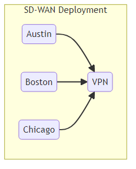

The following code snippet shows a possible TOSCA service template from which this service could be deployed:

```yaml
description: Template for deploying SD-WAN with three sites.
service_template:
  inputs:
    location1:
      type: Location
      default: Austin
    location2:
      type: Location
      default: Boston
    location3:
      type: Location
      default: Chicago

  node_templates:
    sdwan:
      type: VPN

    site1:
      type: VPNSite
      properties:
        location: { $get_input: location1 }
      requirements:
      - vpn: sdwan

    site2:
      type: VPNSite
      properties:
        location: { $get_input: location2 }
      requirements:
      - vpn: sdwan

    site3:
      type: VPNSite
      properties:
        location: { $get_input: location3 }
      requirements:
      - vpn: sdwan
```

As defined here, this template can only be used to deploy an SD-WAN with three sites. To deploy a different number of sites, additional service templates must be created, one for each possible number of SD-WAN sites. This leads to undesirable template proliferation. The next section presents an alternative.

To avoid the need for multiple service templates, TOSCA allows all VPN Site nodes to be created from the same Site node template in the service template. The TOSCA node template definition grammar uses a `count` keyname that specifies the requested number of runtime representations for this node template. This `count` keyname is similar to the `count` keyname in requirement definitions.

The grammar for the `count` keyname is as follows:

| Keyname | Mandatory | Type | Description |
| --- | --- | --- | --- |
| `count` | no | int | The optional number of nodes in the representation graph that will be created from this node template. If not specified, one single node is created. |

It is expected that the value of the `count` is provided as an input to the service template. This enables the creation of a simplified SD-WAN service template that contains only one single VPN Site node as shown in the following figure:

**Figure 10: TOSCA Service Template with Single VPN Site Node**

[figure not shown]

An implementation of such a service template is shown in the following code snippet:

```yaml
tosca_definitions_version: tosca_2_0
description: Template for deploying SD-WAN with a variable number of sites.
capability_types:
  Linkable: {}
relationship_types:
  LinksTo: {}
node_types:
  VPN:
    description: A VPN service
    capabilities:
      linkable:
        type: Linkable
  VPNSite:
    description: A VPN site
    requirements:
      - vpn:
          capability: Linkable
          relationship: LinksTo
          count_range: [1, 1]
service_template:
  inputs:
    number-of-sites:
      type: integer
      default: 3
  node_templates:
    sdwan:
      type: VPN
    site:
      type: VPNSite
      count: { $get_input: number-of-sites }
      requirements:
      - vpn: sdwan
```

## 14.2 Node-Specific Input Values

The service template in the previous section conveniently ignores the location property of the Site node. As shown earlier, the location property is expected to be provided as an input value. If Site node templates can be instantiated multiple times, then it follows that multiple input values are required to initialize the location property for each of the Site node representations.

To allow specific input values to be matched with specific node representations, each node representation is assigned a unique index to differentiate it from other nodes representations created from the same node template. This index is accessed using the `$node_index` function that retrieves the index of the node in the context of which `$node_index` is used. This can then be used to index the list of input values.

The node index for a node representation is immutable: it never changes during the lifetime of that node representation, even if node representations are added or deleted after the service has been deployed.

The following service template shows how the `$node_index` function is used to retrieve specific values from a list of input values in a service template:

```yaml
tosca_definitions_version: tosca_2_0
description: Template for deploying SD-WAN with a variable number of sites.
data_types:
  Location:
    description: A location
    derived_from: string
capability_types:
  Linkable: {}
relationship_types:
  LinksTo: {}
node_types:
  VPN:
    description: A VPN service
    capabilities:
      linkable:
        type: Linkable
  VPNSite:
    description: A VPN site
    properties:
      location:
        type: Location
    requirements:
      - vpn:
          capability: Linkable
          relationship: LinksTo
service_template:
  inputs:
    number-of-sites:
      type: integer
    location:
      type: list
      entry_schema: Location
  node_templates:
    sdwan:
      type: VPN
    site:
      type: VPNSite
      count: { $get_input: number-of-sites }
      properties:
        location: { $get_input: [ location, $node_index ] }
      requirements:
      - vpn: sdwan
```

## 14.3 Cardinality of Relationships

We may also need to accommodate scenarios where a node template with multiple representations defines a requirement to another node template that also has multiple representations. This section introduces grammar for specifying the cardinality of such requirements. Specific mechanisms depend on the type of the relationships to be established.

### 14.3.1 Many-to-One Relationships

In the SD-WAN service template above, each of the site node representations has a relationship to a VPN node that can only be instantiated once. This is an example of a *many-to-one* relationship which is shown in the following figure:

**Figure 11: SD-WAN Service Template with Many-to-One Relationship**

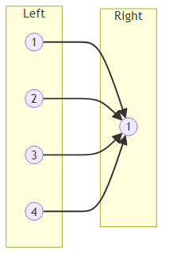

This scenario is supported using existing relationship syntax as shown in the following code snippet:

```yaml
service_template:
  inputs:
    number-of-left:
      type: integer
      default: 1
  node_templates:
    right:
      type: Right
    left:
      type: Left
      count: { $get_input: number-of-left }
      requirements:
      - uses: right
```

### 14.3.2 One-to-Many Relationships

An example of a *one-to-many* relationship is shown in the following figure:

**Figure 12: Service Template with One-to-Many Relationship**

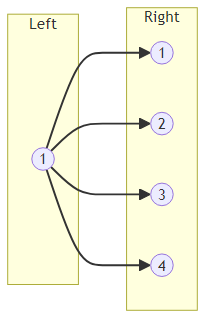

*One-to-many* relationships are less common, but they can just as easily be accommodated using existing TOSCA grammar, as long as the requirement in the single node specifies the appropriate `count` value. This is shown in the following code snippet:

```yaml
service_template:
  inputs:
    number-of-right:
      type: integer
      default: 1
  node_templates:
    right:
      type: Right
      count: { $get_input: number-of-right }
    left:
      type: Left
      requirements:
      - uses:
          node: Right
          count: { $get_input: number-of-right }
```

In this example, a total number of `count` relationships will be created from the single "left" node to the group of "right" nodes. The orchestrator must select a different "right" node for each relationship. If the `count` value is not specified in the "uses" requirement, it defaults to 1 and the orchestrator will only establish one single relationship to one of the "right" nodes. The choice of which one of the several "right" nodes is selected is implementation-specific.

### 14.3.3 Full Mesh

In a *full mesh* scenario, all nodes on the left establish relationships to all of the nodes on the right as shown in the following figure:

**Figure 13: Service Template with Full Mesh Relationships**

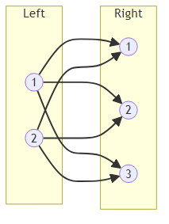

Note that the many-to-one and one to-many pattern are just special cases of a full-mesh when either the number of nodes on the left or the number of nodes on the right side is 1.

As before, the full mesh scenario can easily be defined using existing requirement syntax as shown in the following code snippet:

```yaml
service_template:
  inputs:
    number-of-left:
      type: integer
      default: 1
    number-of-right:
      type: integer
      default: 1
  node_templates:
    right:
      type: Right
      count: { $get_input: number-of-right }
    left:
      type: Left
      count: { $get_input: number-of-left }
      requirements:
      - uses:
          node: Right
          count: { $get_input: number-of-right }
```

### 14.3.4 Matched Pairs

For some services, representations created from different node templates must remain matched up in pairs. For example, let's extend the SD-WAN service above with a third node template that represents a virtual PE router that must be used at each site. Let's assume that Site nodes establish a HostedOn relationship to the vPE nodes. The extended service topology is shown in the following figure:

**Figure 14: SD-WAN Service Template showing Matched Pairs**

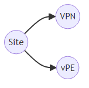

In this example, the intent is for each site node to remain paired with its own vPE node for that site. A generic illustration of the *matched pairs* scenario is shown in the following figure:

**Figure 15: Generic Matched Pairs Example**

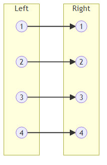

To create matched pairs, the service template designer must first make sure that the number of nodes on the left matches the number of nodes on the right by using the same input value for the `count` keynames in both the "left" and "right" node templates. In addition, each requirement must correctly match source nodes and target nodes are matched correctly, which can be accomplished by making sure that a target node of each relationship has the same node index value as its source node. This following code snippet shows requirement definition grammar that uses the `$node_index` function to uniquely identify target nodes:

```yaml
service_template:
  inputs:
    number-of-nodes:
      type: integer
      default: 1
  node_templates:
    right:
      type: Right
      count: { $get_input: number-of-nodes }
    left:
      type: Left
      count: { $get_input: number-of-nodes }
      requirements:
      - uses: [ right, $node_index ]
```

### 14.3.5 Random Pairs

Some scenarios require nodes to be organized in pairs, but the ordering of the nodes is not important. The following figure shows and such a *random pairs* example:

**Figure 16: Service Template Showing Random Pairs**

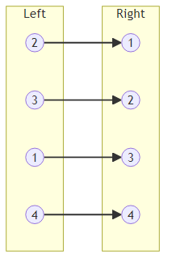

In this scenario, it is not important how target nodes are paired with source nodes, as long as each target node is only used once. To make sure each target node is only used once, the `allocations` keyname in the requirement can be used as shown in the following code snippet:

```yaml
service_template:
  inputs:
    number-of-nodes:
      type: integer
      default: 1
  node_templates:
    right:
      type: Right
      count: { $get_input: number-of-nodes }
      capabilities:
        feature:
          properties:
            target-count: 1
    left:
      type: Left
      count: { $get_input: number-of-nodes }
      requirements:
      - uses:
          node: Right
          allocation:
            target-count: 1
```

This scenario works as follows:

- The target capability in each target node defines a property that is intended to restrict how many times that capability can be targeted. In the example above, the "right" nodes are the target nodes. These nodes define a "feature" capability that in turn defines a "target-count" property. The value of this property is set to 1 to only allow one single incoming relationship.
- The requirement in each source node includes an `allocations` section that allocates a single unit from the target capability. In the example above, the "left" nodes define a "uses" requirement that allocates a single unit from the "target-count" property in the target capability.
- When a relationship is established to a target node, that target node's "target_count" property is exhausted and no additional incoming relationships will be established. This ensures that each target node is only allocated once.